# Cryptic_gating

2023-05-06

# Fluoresence microscopy experiments

An Incucyte was used to image plates of cells transfected with various mCherry or mSclaret-encoding constructs. Even columns had dox-induced TDP-43 knockdown.

Quantification was performed using CellProfiler.

Additionally, for some experiments Nanopore was performed, which is also quantified.

## Generate images from the first plate and mScarlet control from second

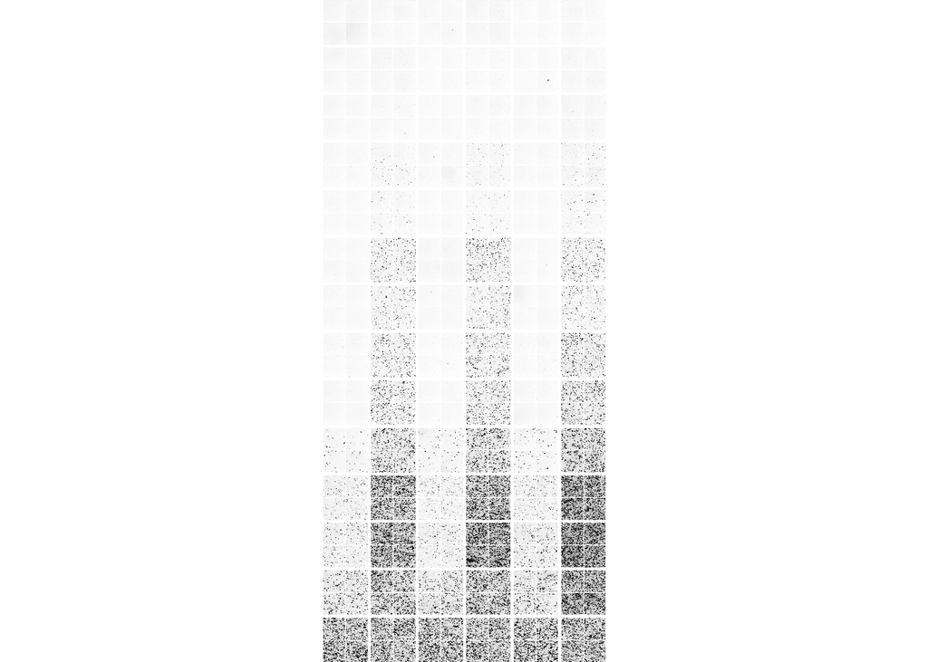

```r
generate_full_image <- function(combined_positions, all_images, n_rows,
                                n_columns=6, dim_image=200, spacing_images=5,
                                spacing_wells=30, background_quantile=0.97){

  # This function makes a plot from incucyte data.
  # You need to supply a "combined_positions" dataframe that has values for
  # plate, well and Order

  # Currently it only works when you have four images per well (stupidly named "replicates")

  height <- n_rows*(2*dim_image + spacing_images) + (n_rows-1)*spacing_wells + 1
  width <- n_columns*(2*dim_image + spacing_images) + (n_columns-1)*spacing_wells + 1

  full_image <- matrix(nrow = height, ncol = width, 0)

  background <- 10000000 # set arbitrarily large initial value

  for(image in all_images){
    filename <- word(image, sep="/", start=-1, end = -1)
    plate <- paste(ifelse(str_detect(image, "control plate"), 2, 1))

    well = word(filename, sep="_", start=2, end=2)
    plate_column = as.numeric(str_sub(well, 2, 3))

    image_column = ifelse(plate_column %% 6 == 0, 6, plate_column %% 6)
    image_row = unique(combined_positions$Order[which(combined_positions$well == well &
                                                        combined_positions$Plate == plate)])

    if(is.na(image_row)){
      next
    }

    if("replicate" %in% colnames(combined_positions)){
      replicate <- combined_positions$replicate[which(combined_positions$filename == filename)]
    } else {
      replicate = as.numeric(word(filename, sep="_", start=3, end=3))
    }

    image_matrix <- readImage(image)
    smaller <- as.array(EBImage::resize(image_matrix, w=dim_image, h=dim_image))

    well_top_left_x = (image_column - 1)*(2*dim_image + spacing_images + spacing_wells) + 1

    image_top_left_x = well_top_left_x + ifelse(replicate %in% c(2,4), dim_image + spacing_images, 0)

    well_top_left_y = (image_row - 1)*(2*dim_image + spacing_images + spacing_wells) + 1

    image_top_left_y = well_top_left_y + ifelse(replicate %in% c(3,4), dim_image + spacing_images, 0)

    full_image[image_top_left_y:(image_top_left_y+dim_image-1),
               image_top_left_x:(image_top_left_x + dim_image-1)] <- smaller

    this_background <- quantile(smaller, 0.05)

    if(this_background < background){
      background <- this_background
    }
  }

  full_image2 <- full_image - background
  img_invert <- Image(1 - t(full_image2/quantile(full_image2, background_quantile)))

  return(img_invert)
}

# Red channel images from 96 well plate - internal cryptics
images_96 <- Sys.glob(paste0(data_dir, "oscar 12_05_2022/96 well red/*.png"))
# Red channel images from second 96 well plate - AARS1 upstream and controls
images_24 <- Sys.glob(paste0(data_dir, "oscar 12_05_2022/control plate red/*.png"))

all_images <- c(images_96, images_24)

all_files <- unique(word(all_images, sep="/", start=-1, end = -1))

position_df <- data.frame(filename = all_files) %>%
  mutate(well = word(filename, sep="_", 2, 2)) %>%
  mutate(Plate = ifelse(str_detect(filename, "96"), 1, 2)) %>%
  mutate(col = as.numeric(str_sub(well, 2, 3))) %>%
  mutate(Position = paste0(str_sub(well, 1, 1), ifelse(col <= 6, "1-6", "7-12")))

positions <- read_csv("small_data_files/Plate positions for 12_05_2022 incucyte.csv") %>%
  mutate(row = 1:n())
combined_positions <- position_df %>%
  left_join(positions, by = c("Position", "Plate"))

img <- generate_full_image(combined_positions, all_images, n_rows = 14)
display(img)
```

```r
writeImage(img, "markdown_images/mScar/mScarlet_inverted_ordered.jpeg", quality=90)
```

## mCherry constructs

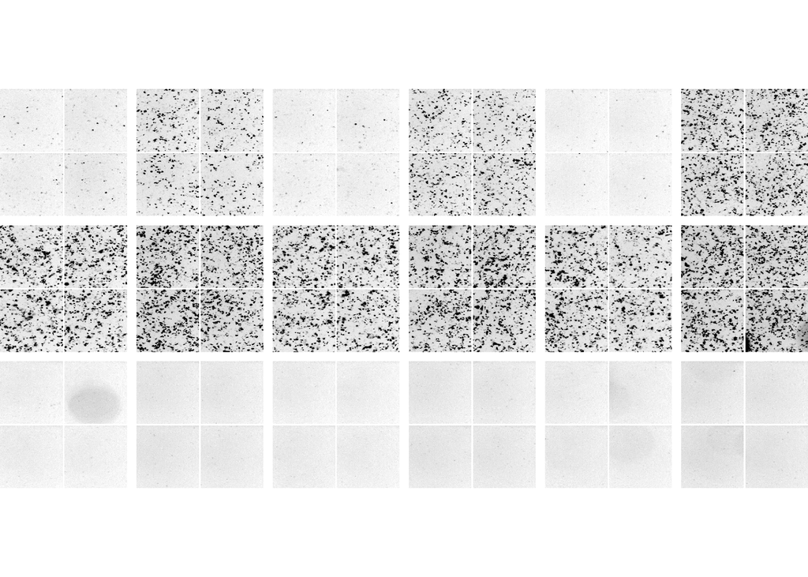

```r
combined_positions_mcherry <- combined_positions %>%
  select(-Order) %>%
  mutate(Order = case_when(Construct == "R3" ~ 1,
                           Construct == "mCherry" ~ 2,
                           Construct == "untransfected" ~ 3))
img <- generate_full_image(combined_positions_mcherry, all_images, n_rows = 3)
display(img)
```

```r
writeImage(img, "markdown_images/mCherry/mCherry_inverted_ordered.jpeg", quality=90)

rm(img)
```

### Quantification or fluoresence of the above, first do mScarlet

```r
# Read in the data from each object identitifed by cell profiler
objects_df <- read_csv(paste0(data_dir, "oscar 12_05_2022/cell_profiler_output/incucyte_12_05_2022_lower_thresholdIdentifyPrimaryObjects.csv"))
```

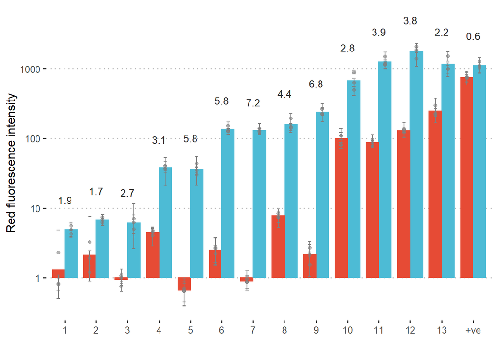

```r
# Summarise to find the total integrated intensity of each image
integrated_df <- objects_df %>%
  group_by(FileName_incucyte_12_05_2022) %>%
  mutate(integrated = sum(Intensity_IntegratedIntensity_incucyte_12_05_2022)) %>%
  select(FileName_incucyte_12_05_2022, integrated) %>%
  unique() %>%
  mutate(well = word(FileName_incucyte_12_05_2022, 2, sep="_")) %>%
  mutate(row = str_sub(well, 1, 1),
         column = as.numeric(str_sub(well, 2, 3))) %>%
  mutate(Plate = ifelse(str_detect(FileName_incucyte_12_05_2022, "96"), 1, 2)) %>%
  mutate(Position = ifelse(column <= 6, paste0(row, "1-6"), paste0(row, "7-12"))) %>%
  left_join(positions, by = c("Position", "Plate")) %>%
  mutate(Treatment = ifelse(column %% 2 == 0, "shTDP", "NT")) %>%
  group_by(well, Plate) %>%
  mutate(mean_red = mean(integrated),
         sd_red = sd(integrated))

# Now calculate summaries for each condition
integrated_summary <- integrated_df %>%
  ungroup() %>%
  group_by(Construct, Treatment) %>%
  mutate(mean_condition = ifelse(mean(mean_red) < 0, 0, mean(mean_red)),
         sd_condition = sd(mean_red)) %>%
  select(Construct, mean_condition, sd_condition, Treatment, Order) %>%
  unique() %>%
  group_by(Construct) %>%
  mutate(mean_NT = max(ifelse(Treatment == "NT", mean_condition, -1000000000000))) %>%
  mutate(mean_dox = max(ifelse(Treatment == "shTDP", mean_condition, -100000000000))) %>%
  mutate(log2FC = log2(mean_dox/mean_NT)) %>%
  mutate(diff_frac = (mean_dox-mean_NT)/mean_dox)

# Produce a plot specifically for the mScarlet ones

good_names_df <- data.frame(Order = c(1:14),
                            good_name = factor(c(1:13, "+ve"), levels = c(1:13, "+ve")))

integrated_mscar <- integrated_df %>%
  filter(!is.na(Order)) %>%
  left_join(good_names_df)
integrated_summary_mscar <- integrated_summary %>%
  filter(!is.na(Order)) %>%
  left_join(good_names_df) %>%
  mutate(y_pos = 2.4*max(mean_condition+sd_condition))
ggplot(integrated_mscar, aes(x = factor(good_name), y=mean_red, colour= Treatment, fill = Treatment)) +
  scale_y_log10() +
  geom_bar(data = integrated_summary_mscar, aes(x = factor(good_name), y = mean_condition),
           position = position_dodge(width = 0.8),
           width = 0.8,
           stat="identity", alpha = 1) +
  geom_point(alpha = 0.2, position = position_dodge(width = 0.8), colour = "grey50") +
  geom_errorbar(aes(x = good_name, ymax = (mean_red + sd_red), ymin = (mean_red-sd_red)),
                position = position_dodge(width = 0.8), width = 0.2, colour = "grey50") +
  geom_text(data = integrated_summary_mscar, aes(x = factor(good_name), y = y_pos,
                                                 label = round(log2FC,1)), colour="grey20", size=3.5) +
  ggeasy::easy_rotate_x_labels() +
  ylab("Red fluorescence intensity") +
  xlab("") +
  ggpubr::theme_pubclean() +
  ggeasy::easy_remove_legend() +
  ggsci::scale_fill_npg() +
  ggsci::scale_colour_npg()
```

```r
ggsave("markdown_images/mScar/mScar intensities quantified and ordered.pdf", height = 8, width = 12, units="cm")
```

## Quantify mScarlet results in SHSY5Y cells

We also transfected our constructs into SHSY5Y cells to check that it wasn’t specific only SKNBE2 cells

```r
objects_df <- read_csv(paste0(data_dir, "SHSY5Y incucyte/output_lower_threshold/IdentifyPrimaryObjects.csv"))
```

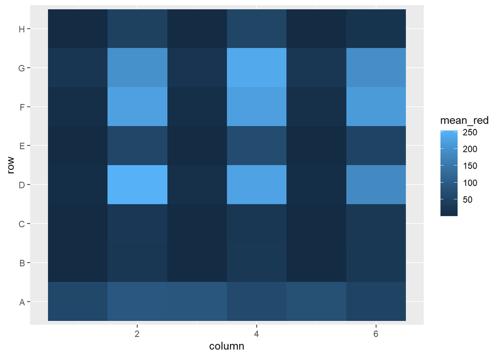

```r
all_image_files <- word(Sys.glob(paste0(data_dir, "SHSY5Y incucyte/as stored/orange/*.png")), -1, sep="/")

positions <- read_csv("small_data_files/Plate positions for 12_05_2022 incucyte.csv")
sh_positions = data.frame(row = c("A", "B", "C", "D", "E", "F", "G", "H"),
                       Construct = c("mScarlet", "A10", "A11", "B5", "B11", "B12", "C2", "C3")) %>%
  left_join(positions) %>%
  mutate(plasmid = factor(case_when(Construct == "mScarlet" ~ "+ve",
                             T~paste0(Order)),
                          levels = c("+ve", "6", "7", "8", "9", "10", "11", "12")))
# Summarise to find the total integrated intensity of each image
integrated_df <- objects_df %>%
  group_by(FileName_incucyte_12_05_2022) %>%
  mutate(integrated = sum(Intensity_IntegratedIntensity_incucyte_12_05_2022)) %>%
  select(FileName_incucyte_12_05_2022, integrated) %>%
  unique() %>%
  full_join(data.frame(FileName_incucyte_12_05_2022 = all_image_files))
integrated_df[is.na(integrated_df)] <- 0

integrated_df2 <- integrated_df %>%
  mutate(well = word(FileName_incucyte_12_05_2022, 2, sep="_")) %>%
  mutate(row = str_sub(well, 1, 1),
         column = as.numeric(str_sub(well, 2, 3))) %>%
  filter(column < 7) %>%
  #left_join(positions, by = c("Position", "Plate")) %>%
  mutate(Treatment = ifelse(column %% 2 == 0, "shTDP", "NT")) %>%
  group_by(well) %>%
  mutate(mean_red = mean(integrated),
         sd_red = sd(integrated)) %>%
  left_join(sh_positions)
ggplot(integrated_df2, aes(x = column, y = row, fill = mean_red)) +
  geom_tile()
```

```r
summary_df <- integrated_df2 %>%
  ungroup() %>%
  select(row, mean_red, sd_red, Treatment) %>%
  unique() %>%
  group_by(row, Treatment) %>%
  mutate(mean_condition = mean(mean_red),
         sd_condition = sd(mean_red)) %>%
  select(row, Treatment, mean_condition, sd_condition) %>%
  unique() %>%
  left_join(sh_positions) %>%
  mutate()
```

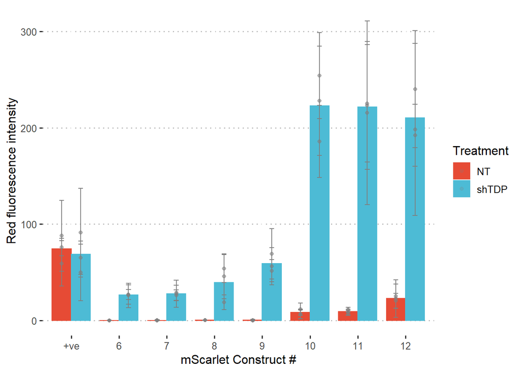

```r
ggplot(integrated_df2, aes(x = plasmid, y=mean_red, colour= Treatment, fill = Treatment)) +
  geom_bar(data = summary_df, aes(x = plasmid, y = mean_condition),
           position = position_dodge(width = 0.8),
           width = 0.8,
           stat="identity", alpha = 1) +
  geom_point(alpha = 0.2, position = position_dodge(width = 0.8), colour = "grey50") +
  geom_errorbar(aes(x = plasmid, ymax = (mean_red + sd_red), ymin = (mean_red-sd_red)),
                position = position_dodge(width = 0.8), width = 0.2, colour = "grey50") +
  ggeasy::easy_rotate_x_labels() +
  ylab("Red fluorescence intensity") +
  xlab("mScarlet Construct #") +
  ggpubr::theme_pubclean() +
  ggsci::scale_fill_npg() +
  ggsci::scale_color_npg() +
  ggeasy::easy_move_legend("right")
```

```r
ggsave("markdown_images/SHSY5Y mScarlet/quantification of SHSY5Y mScarlet.pdf", height = 8, width = 12, units = "cm")
```

### Let’s compare results between SKNDZ and SHSYSY

```r
sk_sh <- integrated_summary_mscar %>%
  ungroup() %>%
  select(Order, sk = mean_dox) %>%
  unique() %>%
  inner_join(summary_df %>% filter(Treatment == "shTDP") %>% select(Order, sh = mean_condition)) %>%
  filter(Order != 14)  # remove positive control
```

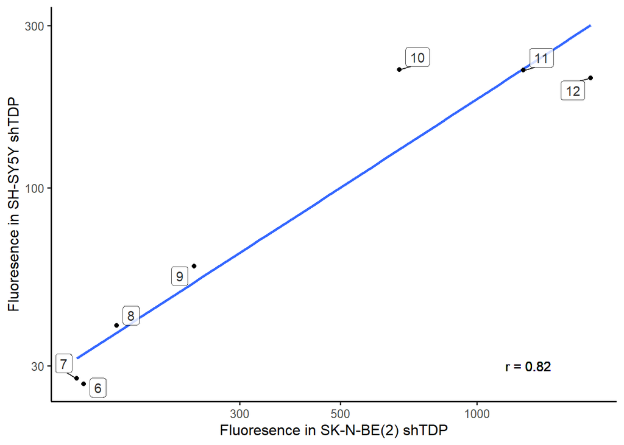

```r
ggplot(sk_sh, aes(x = sk, y = sh)) +
  scale_x_log10() +
  scale_y_log10() +
  geom_smooth(method="lm", se=F) +
  geom_point() +
  xlab("Fluoresence in SK-N-BE(2) shTDP")  +
  ylab("Fluoresence in SH-SY5Y shTDP") +
  ggpubr::theme_classic2() +
  geom_text(aes(x=1300,y=30,label=paste0("r = ", round(cor(sk, sh, method="spearman"),2)))) +
  geom_label_repel(aes(label = paste0(Order)), alpha = 0.8)
```

```r
ggsave("markdown_images/SHSY5Y mScarlet/SHSY5Y versus SKNDZ.pdf", height = 8, width = 8, units = "cm")
```

### And now mCherry in SKNBE2

```r
good_names_mCherry <- c("Cryptic\nmCherry", "Constitutive\nmCherry", "-ve")
good_names_mCherry_df <- data.frame(good_name = factor(good_names_mCherry, levels = good_names_mCherry),
                                    Construct = c("R3", "mCherry", "untransfected"))

integrated_mCherry <- integrated_df2 %>%
  left_join(good_names_mCherry_df) %>%
  select(-Order) %>%
  mutate(Order = case_when(Construct == "R3" ~ 1,
                           Construct == "mCherry" ~ 2,
                           Construct == "untransfected" ~ 3)) %>%
  filter(!is.na(good_name))
integrated_summary_mCherry <- integrated_summary %>%
    left_join(good_names_mCherry_df) %>%
  select(-Order) %>%
  mutate(Order = case_when(Construct == "R3" ~ 1,
                           Construct == "mCherry" ~ 2,
                           Construct == "untransfected" ~ 3)) %>%
  filter(!is.na(good_name)) %>%
  mutate(y_pos = 2.4*max(mean_condition+sd_condition))
```

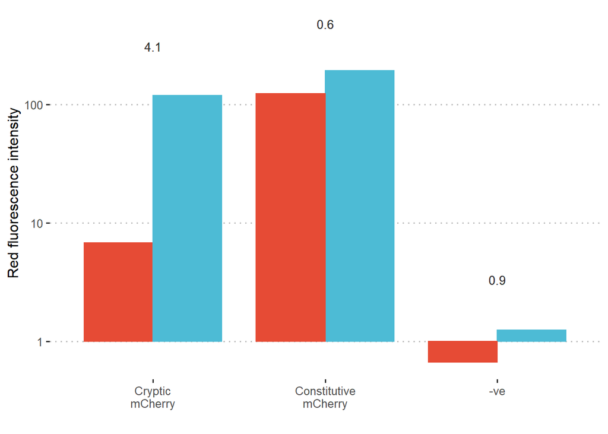

```r
ggplot(integrated_mCherry, aes(x = factor(good_name), y=mean_red, colour= Treatment, fill = Treatment)) +
  scale_y_log10() +
  geom_bar(data = integrated_summary_mCherry, aes(x = factor(good_name), y = mean_condition),
           position = position_dodge(width = 0.8),
           width = 0.8,
           stat="identity", alpha = 1) +
  geom_point(alpha = 0.2, position = position_dodge(width = 0.8), colour = "grey50") +
  geom_errorbar(aes(x = good_name, ymax = (mean_red + sd_red), ymin = (mean_red-sd_red)),
                position = position_dodge(width = 0.8), width = 0.2, colour = "grey50") +
  geom_text(data = integrated_summary_mCherry, aes(x = factor(good_name), y = y_pos,
                                                 label = round(log2FC,1)), colour="grey20", size=3.5) +
  ggeasy::easy_rotate_x_labels() +
  ylab("Red fluorescence intensity") +
  xlab("") +
  ggpubr::theme_pubclean() +
  ggeasy::easy_remove_legend() +
  ggsci::scale_fill_npg() +
  ggsci::scale_color_npg()
```

```r
ggsave("markdown_images/mCherry/mCherry intensities quantified.pdf", height = 7, width = 8, units="cm")

rm(list=setdiff(ls(), "data_dir"))
```

## Cas9 mCherry

We swapped out the AARS1 cryptic exon for a library of potential CEs, each encoding the same part of Cas9.

### Analysis of the Illumina sequencing data

Note that “UPI” stands for “Unique plasmid identifier” i.e. it’s a barcode

This code relies on the output of the python scripts “extract_umis_and_Seqs.py” and “splice_ai_of_cas.py” which are run using a snakemake pipeline.

```r
min_reads <- 7

dox <- read_csv(paste0(data_dir, "Cas9_mCherry/sequencing_analysis/csv/C9D.csv.gz")) %>%
  mutate(treatment = "shTDP") %>%
  left_join(read_csv(paste0(data_dir, "Cas9_mCherry/sequencing_analysis/csv/C9D_consensus.csv")))
nt <- read_csv(paste0(data_dir, "Cas9_mCherry/sequencing_analysis/csv/C9N.csv.gz")) %>%
  mutate(treatment = "NT") %>%
  left_join(read_csv(paste0(data_dir, "Cas9_mCherry/sequencing_analysis/csv/C9N_consensus.csv")))
pred <- read_csv(paste0(data_dir, "Cas9_mCherry/sequencing_analysis/spliceai/spliceai_results.csv"))
#pred <- read_csv(paste0(data_dir, "Cas9_mCherry/sequencing_analysis/spliceai/yo.csv"))

# Combine data from each and calculate the fraction of reads that are cryptic etc
# Filter just for plasmids which were detected in both

combined <- bind_rows(dox, nt) %>%
  # remove PCR duplicates
  distinct(treatment, upi, umi, .keep_all = T) %>%
  # get summaries
  group_by(treatment, upi) %>%
  # analyse fractions
  mutate(total = sum(with_CE + no_CE + intron1_IR + intron2_IR + both_IR)) %>%
  mutate(frac = sum(with_CE)/total) %>%
  select(upi, treatment, frac, total, seq, total) %>%
  unique() %>%
  ungroup() %>%
  filter(!is.na(frac))

# Filter for those that we have sequence data for and pivot wider
pivoted <- combined %>%
  ungroup() %>%
  dplyr::select(upi, treatment, frac, seq, total) %>%
  pivot_wider(names_from = treatment, values_from = c("frac", "seq", "total")) %>%
  ungroup() %>%
  mutate(seq2 = case_when(is.na(seq_shTDP) & is.na(seq_NT) ~ "unclear",
                          is.na(seq_shTDP) ~ seq_NT,
                          is.na(seq_NT) ~ seq_shTDP,
                          seq_shTDP != seq_NT ~ "different",
                          seq_shTDP == seq_NT ~ seq_NT)) %>%
  mutate(seq2 = ifelse(seq2 == "unclear", NA, seq2))

pivoted_just_good <- pivoted %>%
  select(-seq_shTDP, -seq_NT) %>%
  left_join(pred) %>%
  filter(!str_detect(seq2, "N"),
         str_length(seq2) == 154) %>%
  filter(!is.na(acc)) %>%
  mutate(score = acc+don)
```

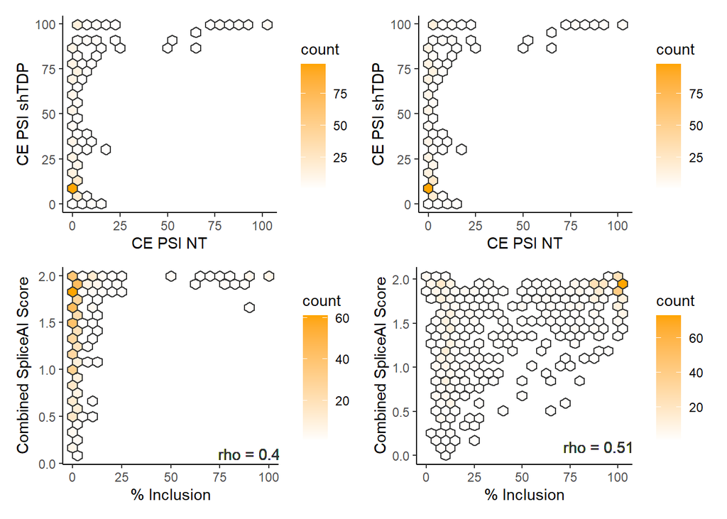

```r
plot_nt_spliceai <- ggplot(pivoted_just_good %>%
  filter(total_NT > min_reads), aes(x = 100*frac_NT, y = score, colour="grey20")) +
  geom_hex(bins=20) +
  scale_fill_gradient2(low="grey100", high="orange", mid = "grey100") +
  theme_classic() +
  scale_color_identity() +
  geom_text(aes(x=90,y=0.1,label=paste0("rho = ", round(cor(score, frac_NT, method="spearman"),2)))) +
  xlab("% Inclusion") +
  ylab("Combined SpliceAI Score")

plot_dox_spliceai <- ggplot(pivoted_just_good %>%
  filter(total_shTDP > min_reads), aes(x = 100*frac_shTDP, y = score, colour="grey20")) +
  geom_hex(bins=20) +
  scale_fill_gradient2(low="grey100", high="orange", mid = "grey100") +
  theme_classic() +
  scale_color_identity() +
  geom_text(aes(x=90,y=0.1,label=paste0("rho = ", round(cor(score, frac_shTDP, method="spearman"),2)))) +
  xlab("% Inclusion") +
  ylab("Combined SpliceAI Score")

#ggsave("markdown_images/mCherry/splice_correlations.pdf", height = 7, width = 17, units="cm")


pivoted_high_both <- pivoted_just_good %>%
  filter(total_shTDP > min_reads & total_NT > min_reads)

plot_psi_comparison <- ggplot(pivoted_high_both, aes(x = 100*frac_NT, y = 100*frac_shTDP, colour = "grey20")) +
  geom_hex(bins=20) +
    scale_fill_gradient2(low="grey100", high="orange", mid = "grey100") +
  theme_classic() +
  scale_color_identity() +
  ylab("CE PSI shTDP") +
  xlab("CE PSI NT")

(plot_psi_comparison | plot_psi_comparison) / (plot_nt_spliceai | plot_dox_spliceai)
```

```r
ggsave("markdown_images/mCherry/all_three_cas9_plots.pdf", height=14, width=18, units="cm")
```

### Analysis of cas9 mCherry fluoresence

```r
objects_df <- read_csv(paste0(data_dir, "Cas9_mCherry/cell_profiler_output/cas9_design2_mChIdentifyPrimaryObjects.csv"))
```

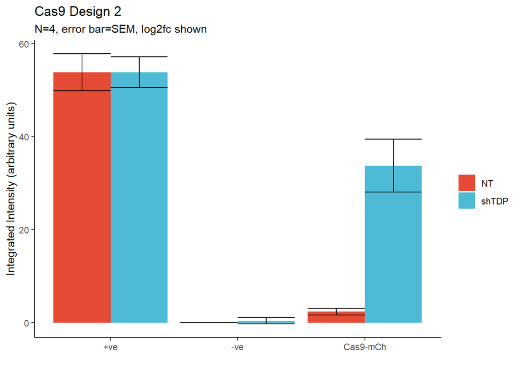

```r
plasmids = c("+ve", "A11", "Cas9-mCh", "-ve")

position_df <- data.frame(row = c("A", 'B', 'C', 'D'),
                          plasmid = factor(plasmids, levels = c("+ve", "-ve", "Cas9-mCh", "A11")))

# Summarise to find the total integrated intensity of each image
integrated_df <- objects_df %>%
  group_by(FileName_incucyte_12_05_2022) %>%
  mutate(integrated = sum(Intensity_IntegratedIntensity_incucyte_12_05_2022)) %>%
  select(FileName_incucyte_12_05_2022, integrated) %>%
  unique() %>%
  mutate(well = word(FileName_incucyte_12_05_2022, 2, sep="_")) %>%
  mutate(row = str_sub(well, 1, 1),
         column = as.numeric(str_sub(well, 2, 3))) %>%
  mutate(Treatment = ifelse(column %% 2 == 0, "shTDP", "NT")) %>%
  left_join(position_df) %>%
  group_by(plasmid, Treatment) %>%
  mutate(average_intensity = mean(integrated),
         sd_intensity = sd(integrated))
summary_df <- integrated_df %>%
  select(average_intensity, sd_intensity) %>%
  unique()
log2fc_df <- summary_df %>%
  ungroup() %>%
  group_by(plasmid) %>%
  pivot_wider(names_from = Treatment, values_from = c("average_intensity", "sd_intensity")) %>%
  mutate(log2fc = log2(average_intensity_shTDP/average_intensity_NT))

log2fc_summary_df <- summary_df %>%
  left_join(log2fc_df %>% select(plasmid, log2fc)) %>%
  ungroup() %>%
  group_by(plasmid) %>%
  mutate(ymax = max(average_intensity+sd_intensity/sqrt(3))) %>%
  ungroup() %>%
  select(plasmid, ymax, log2fc) %>%
  unique()
ggplot(summary_df %>% filter(plasmid != "A11"),
       aes(x = plasmid, y = average_intensity)) +
  geom_bar(stat="identity", position="dodge",
           aes(fill = Treatment)) +
  geom_errorbar(aes(ymin = average_intensity-sd_intensity/sqrt(3),
                    ymax = average_intensity+sd_intensity/sqrt(3),
                    fill = Treatment),
                position="dodge") +
  ylab("Integrated Intensity (arbitrary units)") +
  xlab("") +
  ggtitle("Cas9 Design 2",
          "N=4, error bar=SEM, log2fc shown") +
  theme_classic() +
  ggeasy::easy_remove_legend_title() +
  ggsci::scale_fill_npg() #+
```

```r
  # geom_text(data = log2fc_summary_df %>%
  #             filter(plasmid!="A11") , aes(x = plasmid, y = ymax+3, label = signif(log2fc, 2)))

ggsave("markdown_images/mCherry/Cas9_mCherry_quantification.pdf", height = 8, width = 10, units= "cm")

rm(list=setdiff(ls(), "data_dir"))
```

## Raver rescue

To help demonstrate that the expression of mScarlet above is specifically due to TDP-43 knockdown, we tried a similar experiment to before, except that either function or non-functional (2FL mutant) TDP-43/Raver1 fusion protein, which is known to rescue TDP-43 loss of splicing function, was co-transfected.

```r
mini_spacing = 5
big_spacing = 15
dim_image = 200
norm_quantile <- 0.995
background_quantile <- 0.02

# Find all relevant image files
image_files <- Sys.glob(paste0(data_dir, "raver rescue/orange/*.png"))

# Assign the layout
image_df <- data.frame(filename = word(image_files, -1, sep="/"),
                       full_dir = image_files) %>%
  mutate(well = word(filename, 2, sep="_")) %>%
  mutate(row = str_sub(well,1,1)) %>%
  mutate(column = as.numeric(str_sub(well, 2, -1)),
         image_number = as.numeric(word(filename, 3, sep="_"))) %>%
  mutate(big_row = ifelse(column <= 6, 1, 2),
         small_row = ifelse(image_number > 2, 2, 1),
         big_column = ifelse(column <= 6, column, column - 6),
         small_column = ifelse(image_number > 2, image_number - 2, image_number)) %>%
  mutate(n_mini_spaces_x = big_column - 1 + small_column - 1,
         n_big_spaces_x = big_column - 1,
         n_mini_spaces_y = big_row - 1 + small_row - 1,
         n_big_spaces_y = big_row - 1,
         n_previous_images_x = 2*(big_column-1) + small_column - 1,
         n_previous_images_y = 2*(big_row-1) + small_row - 1) %>%
  mutate(start_x = 1+n_big_spaces_x*big_spacing + n_mini_spaces_x*mini_spacing + n_previous_images_x*dim_image) %>%
  mutate(start_y = 1+n_big_spaces_y*big_spacing + n_mini_spaces_y*mini_spacing + n_previous_images_y*dim_image)

# Find common normalisation factor
for(filename in image_df$full_dir){
  if(filename == image_df$full_dir[1]){
    all_vals <- sample(as.vector(readImage(filename)), 100)
  } else {
    all_vals <- c(all_vals, sample(as.vector(readImage(filename)), 100))
  }
}

normalisation <- quantile(all_vals, norm_quantile)

background_df <- image_df %>% filter(row == "A")
# Find background, using only Row A as these were untransfected
for(filename in background_df$full_dir){
  if(filename == background_df$full_dir[1]){
    all_vals2 <- sample(as.vector(readImage(filename)), 100)
  } else {
    all_vals2 <- c(all_vals2, sample(as.vector(readImage(filename)), 100))
  }
}

background <- quantile(all_vals, background_quantile)

for(this_row in unique(image_df$row)){
  row_df <- image_df %>%
    filter(row == this_row)

  height = max(row_df$start_y) + dim_image
  width = max(row_df$start_x) + dim_image

  full_image <- matrix(nrow = height, ncol = width, 0)

  for(i in 1:nrow(row_df)){
    this_image <- readImage(row_df$full_dir[i])
    smaller <- as.array(EBImage::resize(this_image, w=dim_image, h=dim_image))

    start_x = row_df$start_x[i]
    start_y = row_df$start_y[i]

    full_image[start_y:(start_y+dim_image-1), start_x:(start_x+dim_image-1)] <- smaller

  }

  img <- Image(1-t((full_image-background)/normalisation))

  writeImage(img, paste0("markdown_images/individual_raver_rescue/Row", this_row, ".jpeg") , quality=90)
}
```

### Now plot the CellProfiler quantification of these images

```r
calculate_errors_y_over_x <- function(x_mean, x_sem, y_mean, y_sem, quant, n = 10000, log2fc = F){
  x_vals <- rnorm(n=n, mean=x_mean, sd = x_sem)
  y_vals <- rnorm(n=n, mean=y_mean, sd = y_sem)

  if(log2fc){
    ratios <- log2(y_vals/x_vals)
    ratios <- ratios[!is.na(ratios)]
  } else {
    ratios <- y_vals/x_vals
  }

  return(quantile(ratios, quant))
}

objects_df <- read_csv(paste0(data_dir, "raver rescue/cell_profiler_output/incuyte rescue analysisIdentifyPrimaryObjects.csv"))
plasmids <- c("mScarlet", "A10", "A11", "B5", "B11", "B12", "C2")
plasmid_df <- data.frame(row = c('B', 'C', 'D', 'E', 'F', 'G', 'H'),
                          plasmid = factor(plasmids, levels = plasmids)) %>%
  mutate(TDP_REG = ifelse(plasmid == "mScarlet", F, T))

positions <- read_csv("small_data_files/Plate positions for 12_05_2022 incucyte.csv")
integrated_df <- objects_df %>%
  group_by(FileName_incucyte_12_05_2022) %>%
  mutate(integrated = sum(Intensity_IntegratedIntensity_incucyte_12_05_2022)) %>%
  select(FileName_incucyte_12_05_2022, integrated) %>%
  unique() %>%
  mutate(well = word(FileName_incucyte_12_05_2022, 2, sep="_")) %>%
  mutate(row = str_sub(well, 1, 1),
         column = as.numeric(str_sub(well, 2, 3)))  %>%
  mutate(dox = ifelse(column %% 2 == 0, "shTDP", "NT"),
         construct = ifelse(column <= 6, "Raver", "2FL")) %>%
  ungroup() %>%
  group_by(dox, construct, row, column) %>%
  mutate(average_intensity_well = mean(integrated)) %>%
  ungroup() %>%
  group_by(dox, construct, row) %>%
  select(average_intensity_well) %>%
  unique() %>%
  mutate(average_intensity = mean(average_intensity_well),
         sd_intensity = sd(average_intensity_well))
summary_df <- integrated_df %>%
  select(average_intensity, sd_intensity) %>%
  unique() %>%
  filter(row != "A")
log2fc_df <- summary_df %>%
  ungroup() %>%
  group_by(dox) %>%
  pivot_wider(names_from = construct, values_from = c("average_intensity", "sd_intensity")) %>%
  mutate(log2fc = log2(average_intensity_2FL/average_intensity_Raver)) %>%
  left_join(plasmid_df) %>%
  left_join(positions %>% dplyr::rename(plasmid = Construct)) %>%
  mutate(good_name = factor(ifelse(plasmid == "mScarlet", "+ve", Order),
                            levels = c("+ve", "6", "7", "9",
                                       "10", "11", "12")))
```

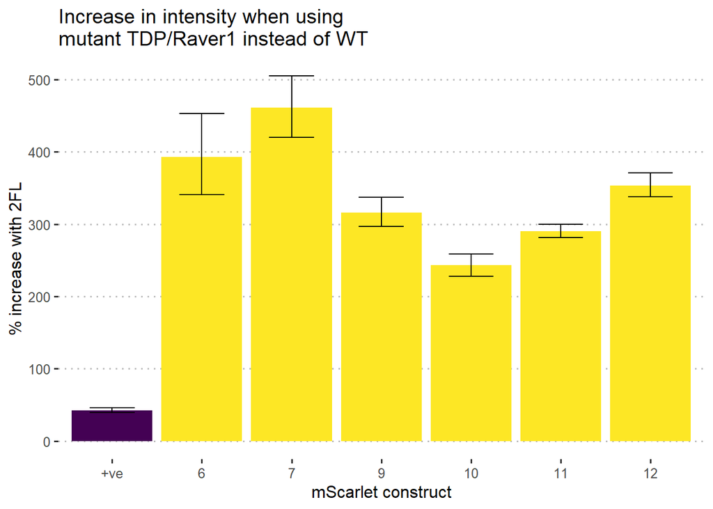

```r
log2fc_df$log2fc_5pc <- mapply(calculate_errors_y_over_x,
                               log2fc_df$average_intensity_Raver,
                               sqrt(log2fc_df$sd_intensity_Raver),
                               log2fc_df$average_intensity_2FL,
                               sqrt(log2fc_df$sd_intensity_2FL),
                               0.05,
                               log2fc = T)
log2fc_df$log2fc_95pc <- mapply(calculate_errors_y_over_x,
                               log2fc_df$average_intensity_Raver,
                               sqrt(log2fc_df$sd_intensity_Raver),
                               log2fc_df$average_intensity_2FL,
                               sqrt(log2fc_df$sd_intensity_2FL),
                               0.95,
                               log2fc = T)
ggplot(log2fc_df %>% filter(dox == "shTDP"),
       aes(x = good_name, y = 100*(2^log2fc)-100, fill = TDP_REG)) +
  geom_bar(stat="identity") +
  ggtitle("Increase in intensity when using\nmutant TDP/Raver1 instead of WT") +
  ylab("% increase with 2FL") +
  geom_errorbar(aes(ymin = 100*(2^log2fc_5pc)-100, ymax = 100*(2^log2fc_95pc)-100,
                    width=0.5)) +
  scale_fill_viridis_d() +
  xlab("mScarlet construct") +
  ggpubr::theme_pubclean() +
  ggeasy::easy_remove_legend()
```

```r
ggsave("markdown_images/mScar/raver_rescue_quantification.pdf", height = 7, width = 10, units="cm")

rm(list=setdiff(ls(), "data_dir"))
```

# Nanopore analysis of splicing

We did lots of Nanopore. We define a term: “productively spliced”. This refers the the % of transcripts that have splicing producing a mature mRNA with the full, uninterrupted CDS for producing the functional protein of interest, and not predicted to be NMD sensitive.

Nanopore analysis here relies primarily on CSV files generated by the python function “extract_splice_junctions_from_bam.py”

Additionally, some plots rely on “pileups” which were generated using a custom pysam-based script, “perform_pileups.py”.

## Nanopore of mScarlet

```r
# Read in splice junction CSVs
all_junction_counts <- Sys.glob(paste0(data_dir,
                                "Nanopore from first mScarlet mCherry 96 plates/extracted splice junctions 96 well/junction_counts/*csv.gz"))

for(f in all_junction_counts){
  print(f)
  if(f == all_junction_counts[1]){
    n <- 0
  }

  bc_f <- word(word(f, sep="/", -1, -1), sep="_", 1, 1)
  bc_r <- word(word(word(f, sep="/", -1, -1), sep="_", 2, 2), sep="\\.", 1)

  this_csv <- read_csv(f, col_types = cols(.default = "?", mapping_quality = "d")) %>%
    mutate(bc_f = bc_f,
           bc_r = bc_r)

  if(nrow(this_csv) == 0){
    next
  }

  n = n+1

  if(n == 1){
    all_csvs <- this_csv
  } else {
    all_csvs <- bind_rows(all_csvs, this_csv)
  }
}
```

[output not shown]

[output cut: 81 more lines]

```r
# Filter just for good alignments
primary <- all_csvs %>%
  mutate(flag_string = ifelse(is.na(flag_string), "", flag_string)) %>%
  filter(!str_detect(flag_string, "not primary|supplementary")) %>%
  filter(mapping_quality > 50) %>%
  mutate(reference = factor(reference, levels = c("d1s", "d2s", "d3s", "A10",
                                                   "A11", "B1", "B2", "B4", "B5",
                                                   "B6", "B11", "B12", "C2", "C3",
                                                   "E1", "E4"))) %>%
  filter(!(reference %in% c("d1s", "d2s", "d3s"))) %>%
  filter(!str_detect(bc_f, "-1")) %>%
  filter(!str_detect(bc_r, "-1")) %>%
  mutate(barcode1 = as.numeric(str_sub(bc_f, 2, 3)),
         barcode2 = as.numeric(str_sub(bc_r, 2, 3)))

primary$junctions[is.na(primary$junctions)] <- ""

# Filter for those that have the expected barcode
positions <- read_csv("small_data_files/Plate positions for 12_05_2022 incucyte.csv") %>%
  mutate(row = 1:n()) %>%
  filter(Plate == 1)
forward_bc_df = data.frame(barcode1 = 1:8, row = str_split("ABCDEFGH", "", simplify = T)[,1:8])

df2 <- primary %>%
  filter(barcode1 > 0 & barcode2 > 0) %>%
  ungroup() %>%
  left_join(forward_bc_df, by = "barcode1") %>%
  mutate(well = paste0(row, barcode2)) %>%
  mutate(Position = paste0(str_sub(well, 1, 1), ifelse(barcode2 <= 6, "1-6", "7-12"))) %>%
  left_join(positions, by = "Position") %>%
  mutate(Construct = str_replace(str_replace(Construct, "Design ", "d"), " stronger", "s")) %>%
  filter(!(Construct %in% c("d1s", "d2s", "d3s"))) %>%
  ungroup()

n_before_filter <- sum(df2$number_of_reads)

df2 <- df2 %>%
  filter(Construct == reference)

n_after_filter <-  sum(df2$number_of_reads)

accuracy = 100*(n_after_filter/n_before_filter)
print(paste("Accuracy =", accuracy, "%"))
```

```
## [1] "Accuracy = 99.3772200152704 %"
```

```r
######## Analyse splicing #########

gtf <- read_tsv(paste0(data_dir, "Nanopore from first mScarlet mCherry 96 plates/combined_gtf.gtf"),
                       col_names = 1:9)
# Calculate what the product splicing junctions should be from the GTF
gtf_productive <- gtf %>%
  group_by(X1) %>%
  filter(X9 %in% c("productive", "downstream")) %>%
  arrange(X4) %>%
  mutate(junc_start = X5-1,
         junc_end = lead(X4)-1) %>%
  dplyr::rename(Construct = X1) %>%
  filter(X9 == "productive") %>%
  mutate(this_splice_string = paste0(junc_start, "-", junc_end)) %>%
  mutate(productive_splice_string = paste0(this_splice_string, collapse = ";")) %>%
  mutate(just_downstream_splice_string = last(this_splice_string)) %>%
  select(Construct, productive_splice_string, just_downstream_splice_string) %>%
  distinct()

# Calculate the fraction that is productively spliced for each condition
df3 <- df2 %>%
  ungroup() %>%
  left_join(gtf_productive %>% select(Construct, productive_splice_string, just_downstream_splice_string)) %>%
  mutate(downstream_is_spliced = str_detect(junctions, just_downstream_splice_string)) %>%
  mutate(is_productive = productive_splice_string == junctions) %>%
  group_by(well) %>%
  mutate(n_productive = sum(as.numeric(is_productive)*number_of_reads)) %>%
  mutate(n_total = sum(number_of_reads)) %>%
  mutate(fraction_productive = n_productive/n_total) %>%
  ungroup() %>%
  mutate(treatment = factor(ifelse(barcode2 %% 2 == 0, "Dox", "NT"), levels = c("NT", "Dox"))) %>%
  select(well, treatment, Construct, fraction_productive) %>%
  unique()
df3_summary <- df3 %>%
  group_by(Construct, treatment) %>%
  mutate(m = mean(fraction_productive),
         sd = sd(fraction_productive)) %>%
  select(Construct, treatment, m, sd) %>%
  unique() %>%
  left_join(positions %>% select(Construct, Order)) %>%
  mutate(good_name = factor(ifelse(Construct == "mScarlet", "+ve", Order),
                            levels = c("+ve", "6", "7", "9",
                                       "10", "11", "12")))
```

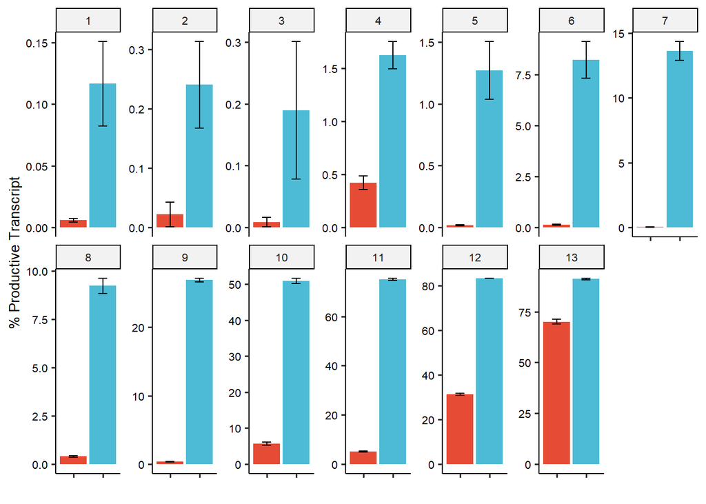

```r
ggplot(df3_summary, aes(x = treatment, fill = treatment, y = 100*m))+
  geom_bar(stat="identity") +
  geom_errorbar(aes(ymin = 100*(m-sd), ymax = 100*(m+sd)), position = "dodge", width = 0.3) +
  facet_wrap(~Order, scales = "free_y", nrow=2) +
  ylim(0, NA) +
  ylab("% Productive Transcript") +
  xlab("") +
  ggpubr::theme_pubr() +
  theme(legend.position = "right", plot.title = element_text(size = 6),
        text = element_text(size = 10),
        axis.text=element_text(size=8),
        axis.text.x=element_blank()) +
  ggeasy::easy_remove_legend() +
  xlab("") +
  ggsci::scale_fill_npg()
```

```r
ggsave("markdown_images/mScar/96_well_productive_transcript_plot.pdf",
       height = 5, width = 10, units = "cm")

rm(list=setdiff(ls(), "data_dir"))
```

### Representatie pileup traces

Let’s also make a pileup of an example mScarlet construct to illustrate that the splicing is as designed by SpliceNouveau

```r
files3 <- Sys.glob(paste0(data_dir,
                          "Nanopore from first mScarlet mCherry 96 plates/pileup 96 well/pileup/*.csv.gz"))

# Get index of files for cols 5 and 6 in the plate for the best internal cryptic
nt <- which(str_detect(files3, "f3_r11"))
dox <- which(str_detect(files3, "f3_r12"))

for(i in c(nt, dox)){
  this_file <- files3[i]

  this_pu <- read_csv(this_file) %>%
    # Ensure that we only look for the correct alignment
    group_by(reference_name) %>%
    mutate(n_this_rname = sum(n)) %>%
    ungroup() %>%
    filter(n_this_rname == max(n_this_rname)) %>%

    # Get coverage
    filter(position %% 1 == 0) %>%
    group_by(position) %>%
    mutate(score = ifelse(nt == "del", 0, n)) %>%
    mutate(n_at_pos = sum(score)) %>%
    select(n_at_pos) %>%
    unique() %>%
    mutate(sample = ifelse(i == nt, "NT", "shTDP")) %>%
    ungroup() %>%
    mutate(frac = n_at_pos / max(n_at_pos))

  if(i == nt){
    coverage_df <- this_pu
  } else {
    coverage_df <- bind_rows(coverage_df, this_pu)
  }
}
```

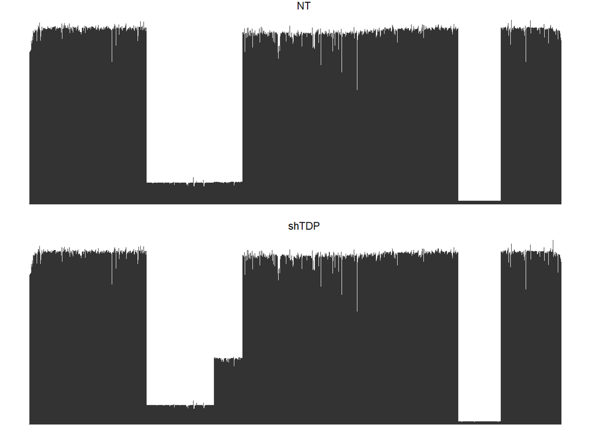

```r
ggplot(coverage_df %>% ungroup(), aes(x = position, y = n_at_pos)) +
  geom_area() +
  facet_wrap(~sample, ncol=1, scales="free_y") +
  theme_void()
```

```r
ggsave("markdown_images/mScar/B11_nano_trace.pdf")
```

## Nanopore of AARS1 mCherry

Although the above mScarlet and this mCherry experiments were performed in parallel, the Nanopore was done separately

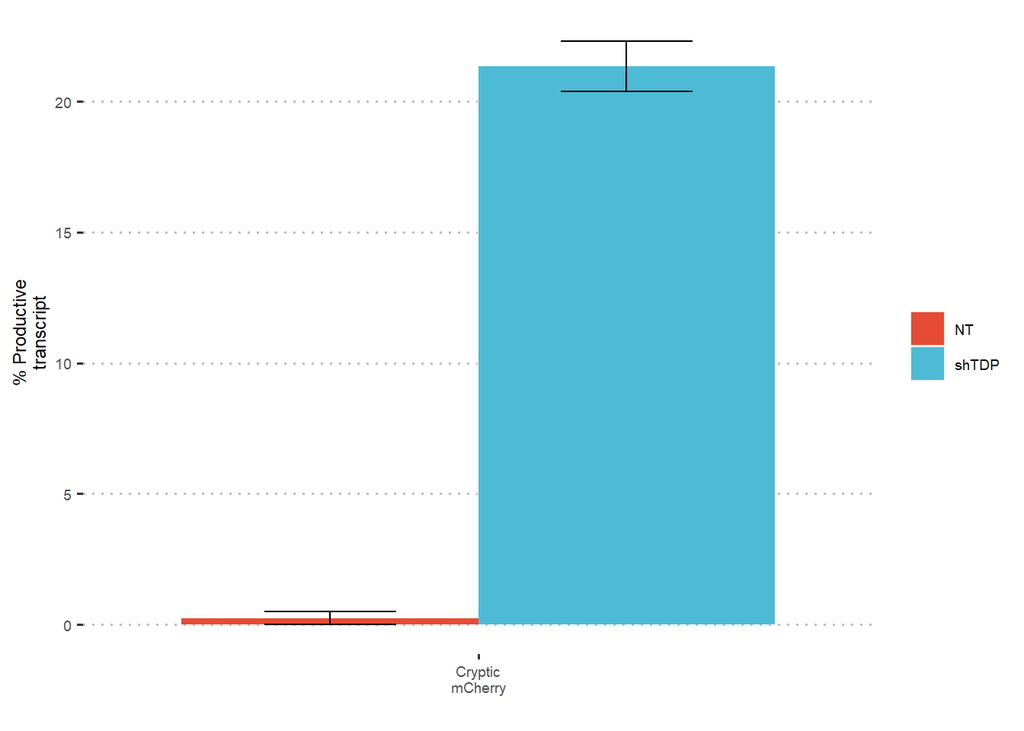

```r
# Read in splice junction CSVs
all_csv <- Sys.glob(paste0(data_dir,
                                "Nanopore from first mScarlet mCherry 96 plates/extracted splice junctions design1 mcherry/*.gz"))

for(filename in all_csv){
  this_df <- read_csv(filename) %>%
    filter(!str_detect(flag_string, "not primary|supplementary")) %>%
    filter(reference == "r3",  # this is the code given to cryptic mCherry vector
           str_detect(junctions, "-1564"),
           mapping_quality > 50,
           first_pos < 80,
           last_pos > 1650) %>%
    mutate(productive = junctions == "175-339;426-655;1470-1564") %>%
    mutate(n_productive = sum(as.numeric(productive)*number_of_reads)) %>%
    mutate(frac_productive = n_productive/sum(number_of_reads)) %>%
    mutate(barcode = as.numeric(word(word(word(filename, -1, -1, sep="/"), 1, 1, sep="\\."), -1, -1, sep="_"))) #%>%
    # dplyr::select(barcode, frac_productive) %>%
    # unique()

  if(filename == all_csv[1]){
    all_df <- this_df
  } else {
    all_df <- bind_rows(all_df, this_df)
  }
}
all_df2 <- all_df %>%
  mutate(treatment = ifelse(barcode %% 2 == 0, "shTDP", "NT")) %>%
  mutate(construct = factor(ifelse(barcode <= 6, "Cryptic\nmCherry", "Constitutive\nmCherry"),
                            levels=c("Cryptic\nmCherry", "Constitutive\nmCherry"))) %>%
  group_by(construct, treatment) %>%
  mutate(mean_pc = 100*mean(frac_productive),
         sd_pc = 100*sd(frac_productive)) %>%
  select(construct, treatment, mean_pc, sd_pc) %>%
  unique()

ggplot(all_df2 %>% filter(construct == "Cryptic\nmCherry"),
       aes(x = construct, y = mean_pc, fill = treatment)) +
  geom_bar(position=position_dodge(width=0.9), stat = "identity", width=0.9) +
  geom_errorbar(aes(ymin = mean_pc-sd_pc, ymax = mean_pc+sd_pc), position = position_dodge(width=0.9), colour="black", width=0.4) +
  ggpubr::theme_pubclean() +
  ggeasy::easy_add_legend_title("") +
  ylab("% Productive\ntranscript") +
  xlab("") +
  theme(legend.position="right", text = element_text(size = 9)) +
  #ggeasy::easy_rotate_x_labels(side="right")  +
  ggsci::scale_fill_npg()
```

```r
ggsave("markdown_images/mCherry/nanopore analysis design 1 mcherry.pdf",
       height = 5, width = 7, units = "cm")

rm(list=setdiff(ls(), "data_dir"))
```

## Nanopore analysis of Triple-Cryptic-Cre

```r
files <- Sys.glob(paste0(data_dir,
                                "Nanopore of triple cryptic cre/junction_counts/*.csv.gz"))

files <- files[which(!str_detect(files, "-1"))]

file <- files[1]
for(file in files){
  print(file)
  bc1 <- word(word(word(file, sep="/", -1, -1), sep="\\.", 1, 1), sep="_", 1, 1)
  bc2 <- word(word(word(file, sep="/", -1, -1), sep="\\.", 1, 1), sep="_", 2, 2)

  csv <- read_csv(file) %>%
    filter(reference == "triple_cryptic_cre") %>%
    filter(!str_detect(flag_string, "not primary|supplementary")) %>%
    filter(!is.na(junctions)) %>%
    mutate(first_cryptic = str_detect(junctions, "235-399;492-721"),
           second_cryptic = str_detect(junctions, "820-984;1083-1312"),
           third_cryptic = str_detect(junctions, "1589-1753;1862-2091")) %>%
    mutate(bc1 = bc1,
           bc2 = bc2) %>%
    mutate(dox = str_detect(bc2, "2|4|6"))

  if(file == files[1]){
    cryptic_df <- csv
  } else {
    cryptic_df <- bind_rows(cryptic_df, csv)
  }
}
```

```
## [1] "G:/My Drive/UCL PhD/Year 4/Cryptic Gating Paper Figures and relevant code/all_data/Nanopore of triple cryptic cre/junction_counts/f10_r1.csv.gz"
```

```
## [1] "G:/My Drive/UCL PhD/Year 4/Cryptic Gating Paper Figures and relevant code/all_data/Nanopore of triple cryptic cre/junction_counts/f10_r2.csv.gz"
```

```
## [1] "G:/My Drive/UCL PhD/Year 4/Cryptic Gating Paper Figures and relevant code/all_data/Nanopore of triple cryptic cre/junction_counts/f10_r3.csv.gz"
```

```
## [1] "G:/My Drive/UCL PhD/Year 4/Cryptic Gating Paper Figures and relevant code/all_data/Nanopore of triple cryptic cre/junction_counts/f10_r4.csv.gz"
```

```
## [1] "G:/My Drive/UCL PhD/Year 4/Cryptic Gating Paper Figures and relevant code/all_data/Nanopore of triple cryptic cre/junction_counts/f10_r5.csv.gz"
```

```
## [1] "G:/My Drive/UCL PhD/Year 4/Cryptic Gating Paper Figures and relevant code/all_data/Nanopore of triple cryptic cre/junction_counts/f10_r6.csv.gz"
```

```
## [1] "G:/My Drive/UCL PhD/Year 4/Cryptic Gating Paper Figures and relevant code/all_data/Nanopore of triple cryptic cre/junction_counts/f11_r1.csv.gz"
```

```
## [1] "G:/My Drive/UCL PhD/Year 4/Cryptic Gating Paper Figures and relevant code/all_data/Nanopore of triple cryptic cre/junction_counts/f11_r2.csv.gz"
```

```
## [1] "G:/My Drive/UCL PhD/Year 4/Cryptic Gating Paper Figures and relevant code/all_data/Nanopore of triple cryptic cre/junction_counts/f11_r3.csv.gz"
```

```
## [1] "G:/My Drive/UCL PhD/Year 4/Cryptic Gating Paper Figures and relevant code/all_data/Nanopore of triple cryptic cre/junction_counts/f11_r4.csv.gz"
```

```
## [1] "G:/My Drive/UCL PhD/Year 4/Cryptic Gating Paper Figures and relevant code/all_data/Nanopore of triple cryptic cre/junction_counts/f11_r5.csv.gz"
```

```
## [1] "G:/My Drive/UCL PhD/Year 4/Cryptic Gating Paper Figures and relevant code/all_data/Nanopore of triple cryptic cre/junction_counts/f11_r6.csv.gz"
```

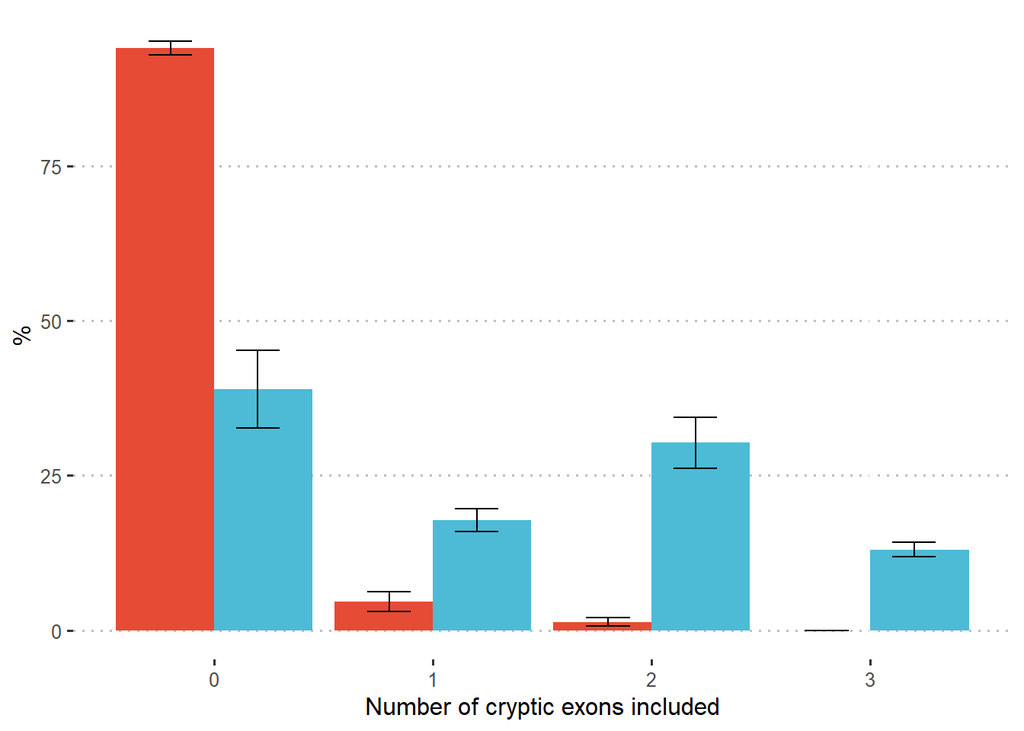

```r
df <- cryptic_df %>%
  filter(bc1 == "f10") %>%
  mutate(ce_string = paste(as.numeric(first_cryptic), as.numeric(second_cryptic),
                           as.numeric(third_cryptic), sep="_")) %>%
  group_by(ce_string, bc2) %>%
  mutate(n = sum(number_of_reads)) %>%
  ungroup() %>%
  group_by(bc2) %>%
  select(bc2, ce_string, n, dox) %>%
  unique() %>%
  mutate(pc = 100*n/sum(n)) %>%
  ungroup() %>%
  select(ce_string, bc2, dox, pc) %>%
  group_by(ce_string, bc2) %>%
  mutate(ce_n = sum(as.numeric(str_split(ce_string, pattern = "_", simplify = T)))) %>%
  ungroup() %>%
  group_by(bc2, ce_n) %>%
  mutate(total_this_n = sum(pc)) %>%
  select(dox, bc2, ce_n, total_this_n) %>%
  unique() %>%
  ungroup() %>%
  group_by(ce_n, dox) %>%
  mutate(mean_pc = mean(total_this_n),
         sd_pc = ifelse(is.na(sd(total_this_n)), 0, sd(total_this_n))) %>%
  select(dox, ce_n, mean_pc, sd_pc) %>%
  unique() %>%
  bind_rows(data.frame(dox = FALSE, ce_n = 3, mean_pc = 0, sd_pc = 0)) # adding so it displays correctly


ggplot(df, aes(x = ce_n, y = mean_pc, fill=dox)) +
  geom_bar(stat="identity", position="dodge") +
  geom_errorbar(aes(x = ce_n, ymin = mean_pc-sd_pc, ymax = mean_pc + sd_pc), position=position_dodge(0.8), width =0.4) +
  xlab("Number of cryptic exons included") +
  ylab("%") +
  #ggtitle("Number of cryptic exons included with/without shTDP") +
  ggpubr::theme_pubclean() +
  ggeasy::easy_remove_legend() +
  ggsci::scale_fill_npg()
```

```r
ggsave("markdown_images/Cre/Cre cryptic plot.pdf", height = 3.5, width = 8, units = "cm")

rm(list=setdiff(ls(), "data_dir"))
```

# Heatmap of SpliceNouveau evolution trajectory

This used a special version of SpliceNouveau which saved the sequence and score after every successful iteration

```r
downsample_amount = 10  # need to downsample otherwise difficult to see

df <- read_csv(paste0(data_dir, "mScarlet_evolution/mscar_track_all5.csv.tracked_scores.csv.gz")) %>%
  group_by(attempt) %>%
  mutate(max_score = max(score)) %>%
  ungroup() %>%
  filter(max_score == max(max_score)) %>%
  filter(position < 1250)
y_df <- df %>%
  select(iteration) %>%
  unique() %>%
  mutate(y = 1:n())

df2 <- df %>%
  left_join(y_df) %>%
  select(position, donor_prob, acceptor_prob, y, score) %>%
  mutate(downsampled = downsample_amount * round(position / downsample_amount)) %>%
  pivot_longer(cols = c("donor_prob", "acceptor_prob")) %>%
  group_by(downsampled, y) %>%
  mutate(ds_value = max(value)) %>%
  ungroup() %>%
  select(downsampled, ds_value, y, score) %>%
  unique()
```

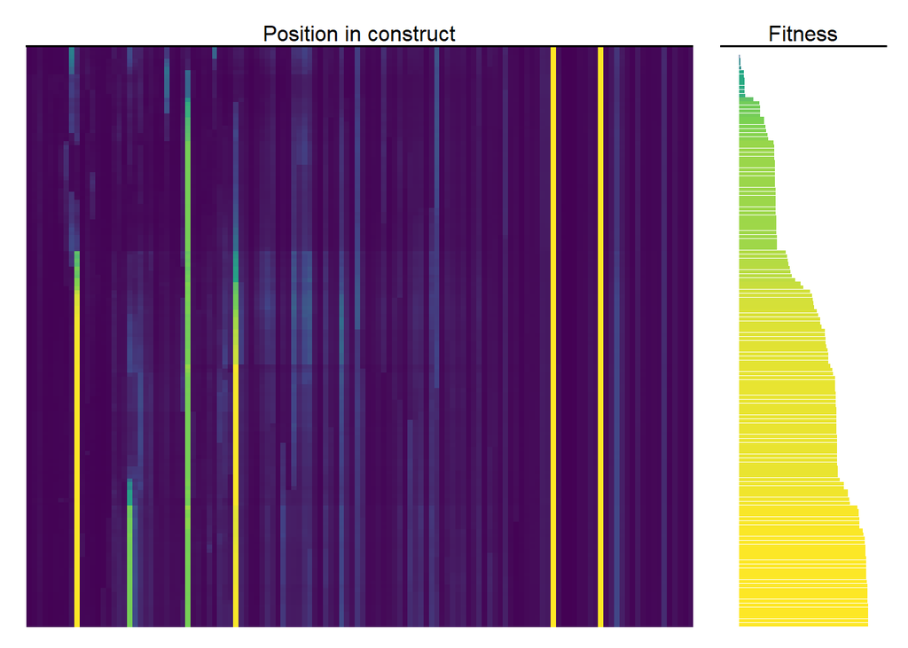

```r
p1 <- ggplot(df2, aes(x = downsampled, y = fct_rev(ordered(y)), fill = (ds_value^0.35))) +
  geom_raster() +
  scale_fill_viridis_c() +
  ggpubr::theme_classic2() +
  xlab("Position in construct") +
  ylab("") +
  ggeasy::easy_remove_legend() +
  ggeasy::easy_remove_y_axis() +
  scale_x_discrete(position = "top")

p2 <- ggplot(df2 %>%
         select(y, score) %>%
         unique(), aes(y = (score-min(score)), x = fct_rev(ordered(y)), fill = log(score-min(score)))) +
  geom_bar(stat="identity") +
  coord_flip() +
  scale_fill_viridis_c() +
  ggpubr::theme_classic2() +
  ggeasy::easy_remove_legend() +
  ggeasy::easy_remove_y_axis() +
  ylab("Fitness") +
  scale_y_discrete(position = "right")

(p1 | p2) + plot_layout(widths = c(4, 1))
```

```r
ggsave("markdown_images/mScar/evolution.pdf", height=10, width=13, units="cm")
```

## Nanopore analysis of Gluc splicing

### Let’s plot the Nanopore

For supplementary we want to plot all five, but for the main fig just plot the best one

```r
files2 <- Sys.glob(paste0(data_dir,
                          "Gluc/junction_counts/*csv.gz"))

files2 <- files2[!str_detect(files2, "no_match")]

for(file in files2){
  print(file)
  df <- data.frame(read_csv(file)) %>%
    mutate(f_bc = as.numeric(str_sub(word(word(file, -1, -1, sep="/"), 1, sep="_"), 2, -1))) %>%
    mutate(r_bc = as.numeric((str_sub(word(word(word(file, -1, -1, sep="/"), 2, sep="_"), 1, sep="\\."), 2, -1)))) %>%
    mutate(last_junction = word(junctions, -1, sep=";")) %>%
    mutate(last_intron_length = as.numeric(word(last_junction, 2, sep="-")) - as.numeric(word(last_junction, 1, sep="-"))) %>%
    mutate(first_junction = word(junctions, 1, sep=";"),
           second_junction = word(junctions, 2, sep=";")) %>%
    mutate(n_introns = str_count(junctions, ";") + 1)

  if(file == files2[1]){
    full_junc_df <- df
  } else {
    full_junc_df <- bind_rows(full_junc_df, df)
  }
}
```

```
## [1] "G:/My Drive/UCL PhD/Year 4/Cryptic Gating Paper Figures and relevant code/all_data/Gluc/junction_counts/F1_R1.csv.gz"
```

```
## [1] "G:/My Drive/UCL PhD/Year 4/Cryptic Gating Paper Figures and relevant code/all_data/Gluc/junction_counts/F1_R2.csv.gz"
```

```
## [1] "G:/My Drive/UCL PhD/Year 4/Cryptic Gating Paper Figures and relevant code/all_data/Gluc/junction_counts/F1_R3.csv.gz"
```

```
## [1] "G:/My Drive/UCL PhD/Year 4/Cryptic Gating Paper Figures and relevant code/all_data/Gluc/junction_counts/F1_R4.csv.gz"
```

```
## [1] "G:/My Drive/UCL PhD/Year 4/Cryptic Gating Paper Figures and relevant code/all_data/Gluc/junction_counts/F1_R5.csv.gz"
```

```
## [1] "G:/My Drive/UCL PhD/Year 4/Cryptic Gating Paper Figures and relevant code/all_data/Gluc/junction_counts/F1_R6.csv.gz"
```

```
## [1] "G:/My Drive/UCL PhD/Year 4/Cryptic Gating Paper Figures and relevant code/all_data/Gluc/junction_counts/F1_R7.csv.gz"
```

```
## [1] "G:/My Drive/UCL PhD/Year 4/Cryptic Gating Paper Figures and relevant code/all_data/Gluc/junction_counts/F2_R1.csv.gz"
```

```
## [1] "G:/My Drive/UCL PhD/Year 4/Cryptic Gating Paper Figures and relevant code/all_data/Gluc/junction_counts/F2_R2.csv.gz"
```

```
## [1] "G:/My Drive/UCL PhD/Year 4/Cryptic Gating Paper Figures and relevant code/all_data/Gluc/junction_counts/F2_R3.csv.gz"
```

```
## [1] "G:/My Drive/UCL PhD/Year 4/Cryptic Gating Paper Figures and relevant code/all_data/Gluc/junction_counts/F2_R4.csv.gz"
```

```
## [1] "G:/My Drive/UCL PhD/Year 4/Cryptic Gating Paper Figures and relevant code/all_data/Gluc/junction_counts/F2_R5.csv.gz"
```

```
## [1] "G:/My Drive/UCL PhD/Year 4/Cryptic Gating Paper Figures and relevant code/all_data/Gluc/junction_counts/F2_R6.csv.gz"
```

```
## [1] "G:/My Drive/UCL PhD/Year 4/Cryptic Gating Paper Figures and relevant code/all_data/Gluc/junction_counts/F2_R7.csv.gz"
```

```
## [1] "G:/My Drive/UCL PhD/Year 4/Cryptic Gating Paper Figures and relevant code/all_data/Gluc/junction_counts/F3_R1.csv.gz"
```

```
## [1] "G:/My Drive/UCL PhD/Year 4/Cryptic Gating Paper Figures and relevant code/all_data/Gluc/junction_counts/F3_R2.csv.gz"
```

```
## [1] "G:/My Drive/UCL PhD/Year 4/Cryptic Gating Paper Figures and relevant code/all_data/Gluc/junction_counts/F3_R3.csv.gz"
```

```
## [1] "G:/My Drive/UCL PhD/Year 4/Cryptic Gating Paper Figures and relevant code/all_data/Gluc/junction_counts/F3_R4.csv.gz"
```

```
## [1] "G:/My Drive/UCL PhD/Year 4/Cryptic Gating Paper Figures and relevant code/all_data/Gluc/junction_counts/F3_R5.csv.gz"
```

```
## [1] "G:/My Drive/UCL PhD/Year 4/Cryptic Gating Paper Figures and relevant code/all_data/Gluc/junction_counts/F3_R6.csv.gz"
```

```
## [1] "G:/My Drive/UCL PhD/Year 4/Cryptic Gating Paper Figures and relevant code/all_data/Gluc/junction_counts/F3_R7.csv.gz"
```

```
## [1] "G:/My Drive/UCL PhD/Year 4/Cryptic Gating Paper Figures and relevant code/all_data/Gluc/junction_counts/F4_R1.csv.gz"
```

```
## [1] "G:/My Drive/UCL PhD/Year 4/Cryptic Gating Paper Figures and relevant code/all_data/Gluc/junction_counts/F4_R2.csv.gz"
```

```
## [1] "G:/My Drive/UCL PhD/Year 4/Cryptic Gating Paper Figures and relevant code/all_data/Gluc/junction_counts/F4_R3.csv.gz"
```

```
## [1] "G:/My Drive/UCL PhD/Year 4/Cryptic Gating Paper Figures and relevant code/all_data/Gluc/junction_counts/F4_R4.csv.gz"
```

```
## [1] "G:/My Drive/UCL PhD/Year 4/Cryptic Gating Paper Figures and relevant code/all_data/Gluc/junction_counts/F4_R5.csv.gz"
```

```
## [1] "G:/My Drive/UCL PhD/Year 4/Cryptic Gating Paper Figures and relevant code/all_data/Gluc/junction_counts/F4_R6.csv.gz"
```

```
## [1] "G:/My Drive/UCL PhD/Year 4/Cryptic Gating Paper Figures and relevant code/all_data/Gluc/junction_counts/F4_R7.csv.gz"
```

```
## [1] "G:/My Drive/UCL PhD/Year 4/Cryptic Gating Paper Figures and relevant code/all_data/Gluc/junction_counts/F5_R1.csv.gz"
```

```
## [1] "G:/My Drive/UCL PhD/Year 4/Cryptic Gating Paper Figures and relevant code/all_data/Gluc/junction_counts/F5_R2.csv.gz"
```

```
## [1] "G:/My Drive/UCL PhD/Year 4/Cryptic Gating Paper Figures and relevant code/all_data/Gluc/junction_counts/F5_R3.csv.gz"
```

```
## [1] "G:/My Drive/UCL PhD/Year 4/Cryptic Gating Paper Figures and relevant code/all_data/Gluc/junction_counts/F5_R4.csv.gz"
```

```
## [1] "G:/My Drive/UCL PhD/Year 4/Cryptic Gating Paper Figures and relevant code/all_data/Gluc/junction_counts/F5_R5.csv.gz"
```

```
## [1] "G:/My Drive/UCL PhD/Year 4/Cryptic Gating Paper Figures and relevant code/all_data/Gluc/junction_counts/F5_R6.csv.gz"
```

```
## [1] "G:/My Drive/UCL PhD/Year 4/Cryptic Gating Paper Figures and relevant code/all_data/Gluc/junction_counts/F5_R7.csv.gz"
```

```
## [1] "G:/My Drive/UCL PhD/Year 4/Cryptic Gating Paper Figures and relevant code/all_data/Gluc/junction_counts/F6_R1.csv.gz"
```

```
## [1] "G:/My Drive/UCL PhD/Year 4/Cryptic Gating Paper Figures and relevant code/all_data/Gluc/junction_counts/F6_R2.csv.gz"
```

```
## [1] "G:/My Drive/UCL PhD/Year 4/Cryptic Gating Paper Figures and relevant code/all_data/Gluc/junction_counts/F6_R3.csv.gz"
```

```
## [1] "G:/My Drive/UCL PhD/Year 4/Cryptic Gating Paper Figures and relevant code/all_data/Gluc/junction_counts/F6_R4.csv.gz"
```

```
## [1] "G:/My Drive/UCL PhD/Year 4/Cryptic Gating Paper Figures and relevant code/all_data/Gluc/junction_counts/F6_R5.csv.gz"
```

```
## [1] "G:/My Drive/UCL PhD/Year 4/Cryptic Gating Paper Figures and relevant code/all_data/Gluc/junction_counts/F6_R6.csv.gz"
```

```
## [1] "G:/My Drive/UCL PhD/Year 4/Cryptic Gating Paper Figures and relevant code/all_data/Gluc/junction_counts/F6_R7.csv.gz"
```

```r
# Analyse whether they primarily align to the correct sequences and check
# whether they are productively spliced

full_junc_df2 <- full_junc_df %>%
  mutate(expected_rname = case_when(r_bc == 1 ~ "design1_Gluc",
                                    r_bc == 2 ~ "Gluc_prepared",
                                    r_bc == 3 ~ "Design2_Gluc_A2",
                                    r_bc == 4 ~ "Design2_Gluc_A3",
                                    r_bc == 5 ~ "Design2_Gluc_A5",
                                    r_bc == 6 ~ "Design2_Gluc_A6",
                                    r_bc == 7 ~ "Design2_Gluc_A7")) %>%
  filter(reference == expected_rname) %>%
  filter(!(r_bc == 1 & f_bc == 5)) %>%
  filter(!(r_bc == 2 & f_bc == 3)) %>%
  filter(last_intron_length == 94) %>%
  mutate(productively_spliced = junctions == case_when(r_bc == 1 ~ "106-270;357-586;1248-1342",
                                                       r_bc == 2 ~ "605-699",
                                                       r_bc == 3 ~ "252-416;477-706;996-1090",
                                                       r_bc == 4 ~ "252-416;477-706;996-1090",
                                                       r_bc == 5 ~ "252-416;477-706;996-1090",
                                                       r_bc == 6 ~ "252-416;477-715;1005-1099",
                                                       r_bc == 7 ~ "252-416;477-715;1005-1099")) %>%
  filter(!str_detect(flag_string, "not primary|supplementary")) %>%
  select(f_bc, r_bc, productively_spliced, expected_rname, number_of_reads) %>%
  unique() %>%
  group_by(f_bc, r_bc) %>%
  mutate(perc_productive = 100*sum(as.numeric(productively_spliced) * number_of_reads) / sum(number_of_reads)) %>%
  dplyr::select(f_bc, r_bc, expected_rname, perc_productive) %>%
  unique() %>%
  mutate(treatment = ifelse(f_bc %% 2 == 0, "shTDP", "NT"))

nano_summary <- full_junc_df2 %>%
  ungroup() %>%
  mutate(good_name = case_when(r_bc == 1 ~ "Upstream",
                               r_bc == 2 ~ "Constitutive",
                               r_bc == 3 ~ "TDP-REGv2\n#1",
                               r_bc == 4 ~ "TDP-REGv2\n#2",
                               r_bc == 5 ~ "TDP-REGv2\n#3",
                               r_bc == 6 ~ "TDP-REGv2\n#4",
                               r_bc == 7 ~ "TDP-REGv2\n#5")) %>%
  mutate(paper_name = case_when(r_bc == 1 ~ "TDP-REGv1",
                                r_bc == 2 ~ "+ve",
                                r_bc == 3 ~ "TDP-REGv2\n#1",
                                r_bc == 4 ~ "TDP-REGv2\n#2",
                                r_bc == 5 ~ "TDP-REGv2\n#3",
                                r_bc == 6 ~ "TDP-REGv2\n#4",
                                r_bc == 7 ~ "TDP-REGv2\n#5")) %>%
  group_by(treatment, good_name) %>%
  mutate(mean_perc = mean(perc_productive),
         sd_perc = sd(perc_productive)) %>%
  select(mean_perc, sd_perc, paper_name) %>%
  unique() %>%
  ungroup() %>%
  group_by(good_name) %>%
  mutate(log2fc = log2(max(mean_perc)/min(mean_perc)))
```

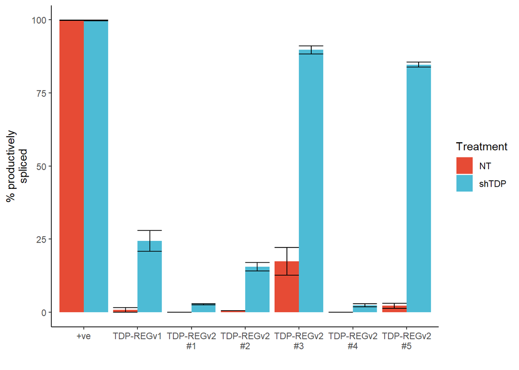

```r
ggplot(nano_summary,
       aes(x = paper_name, y = mean_perc, fill = treatment)) +
  geom_bar(stat="identity", position="dodge") +
  geom_errorbar(aes(ymin = mean_perc - sd_perc, ymax = mean_perc + sd_perc),
                position="dodge") +
  ylab("% productively\nspliced") +
  xlab("") +
  theme_classic() +
  ggeasy::easy_add_legend_title("Treatment")+
  ggsci::scale_fill_npg()
```

```r
ggsave("markdown_images/gluc/all_gluc_nanopore_results.pdf", height = 9, width = 19, units="cm")

nano_plot <- ggplot(nano_summary %>% filter(paper_name %in% c("TDP-REGv1", "TDP-REGv2\n#5")),
       aes(x = paper_name, y = mean_perc, fill = treatment)) +
  geom_bar(stat="identity", position="dodge") +
  geom_errorbar(aes(ymin = mean_perc - sd_perc, ymax = mean_perc + sd_perc),
                position="dodge") +
  ylab("% productively\nspliced") +
  xlab("") +
  theme_classic() +
  ggeasy::easy_add_legend_title("Treatment") +
  ggsci::scale_fill_npg()
```

### Now let’s plot the plate reader of the relevant one and combine

```r
df <- read_csv(paste0(data_dir, "Gluc/oscargluc 23 june 2022.csv")) %>%
  pivot_longer(cols = c(`1`, `2`, `3`, `4`, `5`, `6`, `7`, `8`, `9`, `10`, `11`, `12`)) %>%
  mutate(column = as.numeric(name)) %>%
  select(-name) %>%
  filter(column < 7) %>%
  filter(!(column == 3 & row == "B")) %>% # remove bad well
  mutate(treatment = factor(ifelse(column %% 2 == 0, "shTDP", "NT"), levels = c("NT", "shTDP"))) %>%
  group_by(treatment, row) %>%
  mutate(av = mean(value),
         sd = sd(value))
name_df <- data.frame(row = c("A", "B", "C", "D", "E", "F", "G", "H"),
                      names = c("Design1", "Positive", "A2", "A3", "A5", "A6", "A7", "mScarlet"),
                      clear_name = factor(c("TDP-REGv1", "Constitutive", "TDP-REGv2\n#1", "TDP-REGv2\n#2", "TDP-REGv2\n#3", "TDP-REGv2\n#4", "TDP-REGv2\n#5", "mScarlet"),
                                          levels = c("Constitutive", "mScarlet", "TDP-REGv1", "TDP-REGv2\n#1", "TDP-REGv2\n#2", "TDP-REGv2\n#3", "TDP-REGv2\n#4", "TDP-REGv2\n#5")))

summary <- df %>%
  left_join(name_df) %>%
  ungroup() %>%
  select(clear_name, treatment, av, sd) %>%
  unique() %>%
  group_by(clear_name) %>%
  mutate(shTDP_av = max(ifelse(treatment == "shTDP", av, 0)),
         nt_av = max(ifelse(treatment == "NT", av, 0))) %>%
  mutate(log2fc = log2(shTDP_av/nt_av))
nice_names <- data.frame(clear_name = c("TDP-REGv2\n#3", "TDP-REGv2\n#5", "mScarlet", "TDP-REGv1"),
                         clear_name2 = c("TDP-REGv2\n# 1", "TDP-REGv2\n# 2", "Negative", "AARS1-\nbased"),
                         clear_name3 = factor(c("", "TDP-REGv2\n#5", "Negative", "TDP-REGv1"),
                                              levels = c("TDP-REGv1", "TDP-REGv2\n#5", "Negative", "")))

summary3 <- filter(summary, clear_name %in% c("TDP-REGv2\n#3", "TDP-REGv2\n#5", "mScarlet", "TDP-REGv1")) %>%
  left_join(nice_names)
```

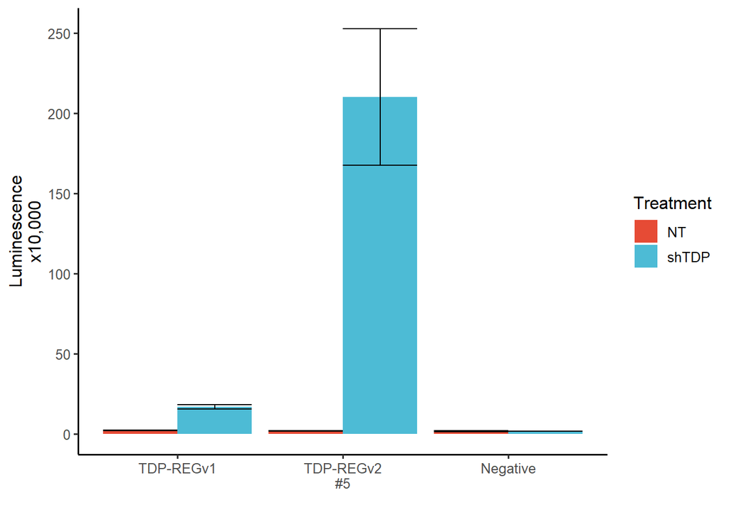

```r
p1 <- ggplot(summary3 %>%
         filter(clear_name3 != ""), aes(x = clear_name3, y = av/10000, fill = treatment)) +
  geom_bar(stat="identity", position = "dodge") +
  geom_errorbar(aes(ymin = (av-sd)/10000, ymax = (av+sd)/10000), position="dodge") +
  #geom_text(aes(label = round(log2fc,2), y = 3000000)) +
  xlab("") +
  ylab("Luminescence\nx10,000") +
  #ggtitle("TDP-43-regulated secreted luciferase signal") +
  ggpubr::theme_classic2() +
  #geom_text(aes(label = round(log2fc,2), y = 300)) +
  ggeasy::easy_add_legend_title("Treatment") +
  ggsci::scale_fill_npg() #+
  #ggeasy::easy_rotate_x_labels(side = "right")
p1
```

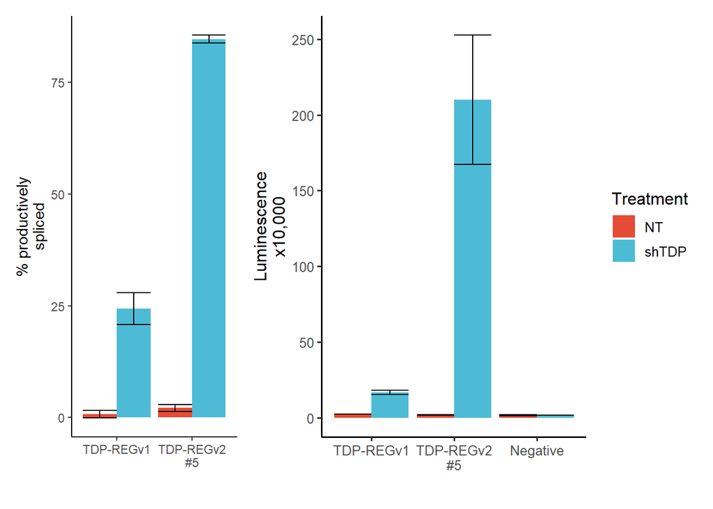

```r
((nano_plot + ggeasy::easy_remove_legend()) | p1) + plot_layout(widths = c(1, 1.6))
```

```r
ggsave("markdown_images/gluc/combined nanopore and luciferase.pdf", width = 19, height = 7, units = "cm")
```

### Produce some representative pileups

This is just to show that the splicing is exactly as predicted

```r
files3 <- Sys.glob(paste0(data_dir,
                          "Gluc/pileup/*.csv.gz"))

# Get index of files for cols 5 and 6 in the plate for the best internal cryptic
nt <- which(str_detect(files3, "F5_R7"))
dox <- which(str_detect(files3, "F6_R7"))


for(i in c(nt, dox)){
  this_file <- files3[i]

  this_pu <- read_csv(this_file) %>%
    filter(insertion_number == 0) %>%
    # Ensure that we only look for the correct alignment
    group_by(reference_name) %>%
    mutate(n_this_rname = sum(n)) %>%
    ungroup() %>%
    filter(n_this_rname == max(n_this_rname)) %>%
    filter(position %% 1 == 0) %>%
    group_by(position) %>%
    mutate(score = ifelse(nt == "del", 0, n)) %>%
    mutate(n_at_pos = sum(score)) %>%
    select(n_at_pos) %>%
    unique() %>%
    mutate(sample = ifelse(i == nt, "NT", "shTDP")) %>%
    ungroup() %>%
    mutate(frac = n_at_pos / max(n_at_pos))

  if(i == nt){
    coverage_df <- this_pu
  } else {
    coverage_df <- bind_rows(coverage_df, this_pu)
  }
}
```

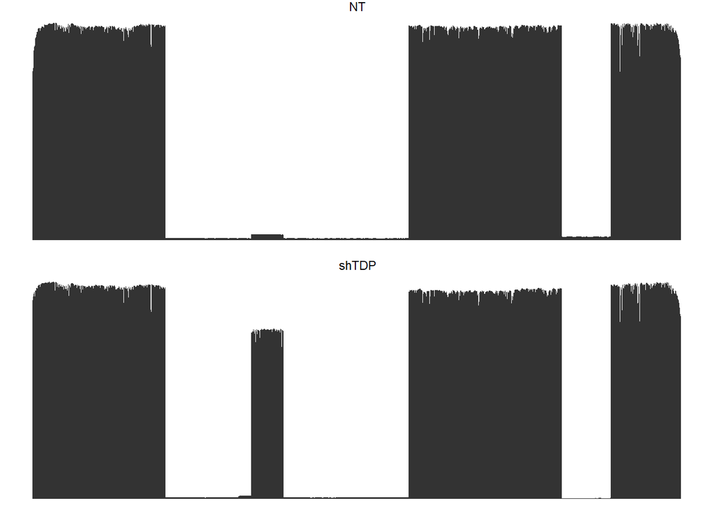

```r
ggplot(coverage_df %>% ungroup(), aes(x = position, y = n_at_pos)) +
  geom_area() +
  facet_wrap(~sample, ncol=1, scales="free_y") +
  theme_void() +
  ggsci::scale_fill_npg()
```

```r
ggsave("markdown_images/gluc/gluc_internal_5_pileups.pdf")
rm(list=setdiff(ls(), "data_dir"))
```

# AAV quantification

We transduced mice with an AAV expressing mCherry. The images were manually quantified (with blinding)

```r
quants <- read_csv(paste0(data_dir, "AAV/quantifications_from_jo_fixed.csv")) %>%
    filter(!is.na(triple)) %>%
  dplyr::rename(tdp_and_vacht = tdp_and_vacth) %>%
  mutate(vacht = as.numeric(vacht)) %>%
  # Compute some useful values
  mutate(n_mcherry_no_vacht = mcherry - vacht_and_mcherry,
         n_vacht_no_tdp = vacht - tdp_and_vacht) %>%

  group_by(id) %>%
  # Compute summaries per animal
  mutate(total_n_mcherry = sum(mcherry),
         total_n_vacht_and_mcherry = sum(vacht_and_mcherry),
         total_n_vacht = sum(vacht),
         total_n_vacht_and_tdp = sum(tdp_and_vacht),
         total_n_mcherry_no_vacht = sum(n_mcherry_no_vacht),
         total_n_vacht_no_tdp = sum(n_vacht_no_tdp),
         total_n_triple = sum(triple),
         total_n_tdp = sum(vacht - n_vacht_no_tdp)) %>%

  select(id, contains("total")) %>%
  unique() %>%

  # Answer question 1:
  mutate(frac_vacht_with_TDP = total_n_vacht_and_tdp/total_n_vacht) %>%

  # Answer question 2:
  mutate(frac_vacht_with_mcherry = total_n_vacht_and_mcherry/total_n_vacht) %>%

  # Answer question 4:
  mutate(n_vacht_mcherry_and_tdp = total_n_triple,
         n_vacht_mcherry_no_tdp = total_n_vacht_and_mcherry - total_n_triple,
         n_vacht_tdp_no_mcherry = total_n_vacht_and_tdp - total_n_triple) %>%
  mutate(n_vacht_no_mcherry_no_tdp = total_n_vacht - n_vacht_mcherry_and_tdp - n_vacht_mcherry_no_tdp - n_vacht_tdp_no_mcherry) %>%

  mutate(genotype = ifelse(id %in% c(29, 30, 31, 40, 206), "cKO", "Control")) %>%

  # Add entry for cKO in which no fluorescence was seen
  bind_rows(data.frame(id = -1, genotype = "cKO")) %>%

  ungroup() %>%
  arrange(desc(genotype)) %>%
  mutate(label = 1:n())
```

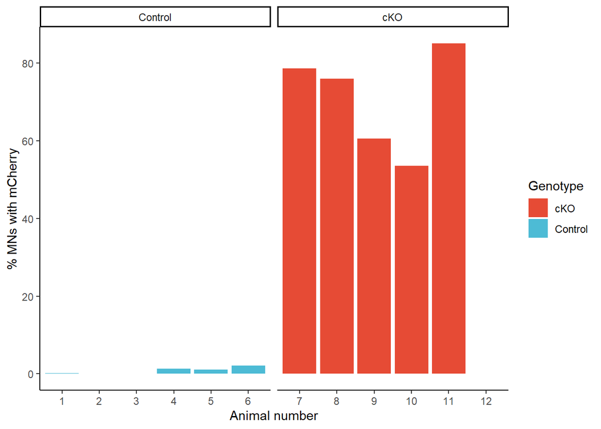

```r
quants[is.na(quants)] <- 0

quants_a244 <- quants

ggplot(quants, aes(x = factor(label), y = 100*frac_vacht_with_mcherry,
                   fill = genotype)) +
  geom_bar(stat="identity") +
  facet_wrap(~factor(genotype, levels = c("Control", "cKO")),
                     scale = "free_x") +
  ylab("% MNs with mCherry") +
  theme_classic() +
  ggsci::scale_fill_npg() +
  xlab("Animal number") +
  ggeasy::easy_add_legend_title("Genotype")
```

```r
ggsave("markdown_images/AAV/pc_mCherry_MNs.pdf", height = 4.5, width = 8, units="cm")

# ggplot(quants, aes(x = factor(label), y = 100*frac_vacht_with_TDP,
#                    fill = genotype)) +
#   geom_bar(stat="identity") +
#   facet_wrap(~factor(genotype, levels = c("Control", "cKO")),
#                      scale = "free_x") +
#   ylab("% MNs with TDP-43") +
#   theme_classic() +
#   ggsci::scale_fill_npg() +
#   xlab("Animal number") +
#   ggeasy::easy_add_legend_title("Genotype")
#
# ggsave("markdown_images/AAV/pc_TDP43_MNs.pdf", height = 4.5, width = 8, units="cm")
```

Now let’s do the same but for the internal cryptic mScarlet

```r
quants <- read_csv(paste0(data_dir, "AAV/a241 quantifications.csv")) %>%
    filter(!is.na(triple)) %>%
    mutate(mcherry = vacht_and_mcherry) %>%
  mutate(vacht = as.numeric(vacht)) %>%
  # Compute some useful values
  mutate(n_mcherry_no_vacht = mcherry - vacht_and_mcherry,
         n_vacht_no_tdp = vacht - tdp_and_vacht) %>%

  group_by(id) %>%
  # Compute summaries per animal
  mutate(total_n_mcherry = sum(mcherry),
         total_n_vacht_and_mcherry = sum(vacht_and_mcherry),
         total_n_vacht = sum(vacht),
         total_n_vacht_and_tdp = sum(tdp_and_vacht),
         total_n_mcherry_no_vacht = sum(n_mcherry_no_vacht),
         total_n_vacht_no_tdp = sum(n_vacht_no_tdp),
         total_n_triple = sum(triple),
         total_n_tdp = sum(vacht - n_vacht_no_tdp)) %>%

  select(id, contains("total")) %>%
  unique() %>%

  # Answer question 1:
  mutate(frac_vacht_with_TDP = total_n_vacht_and_tdp/total_n_vacht) %>%

  # Answer question 2:
  mutate(frac_vacht_with_mcherry = total_n_vacht_and_mcherry/total_n_vacht) %>%

  # Answer question 4:
  mutate(n_vacht_mcherry_and_tdp = total_n_triple,
         n_vacht_mcherry_no_tdp = total_n_vacht_and_mcherry - total_n_triple,
         n_vacht_tdp_no_mcherry = total_n_vacht_and_tdp - total_n_triple) %>%
  mutate(n_vacht_no_mcherry_no_tdp = total_n_vacht - n_vacht_mcherry_and_tdp - n_vacht_mcherry_no_tdp - n_vacht_tdp_no_mcherry) %>%

  mutate(genotype = ifelse(id %in% c(254, 256, 257, 283, 284), "cKO", "Control")) %>%

  # Add entry for cKO in which no fluorescence was seen
  bind_rows(data.frame(id = 255, genotype = "cKO")) %>%

  ungroup() %>%
  arrange(desc(genotype)) %>%
  mutate(label = 1:n())
```

```
## -------------------------------------------------------- Delimiter: "," chr
## (1): section dbl (7): id, vacht, vacht_and_mcherry, tdp_and_vacht, triple, cKO,
## WT lgl (2): ...7, ...8
```

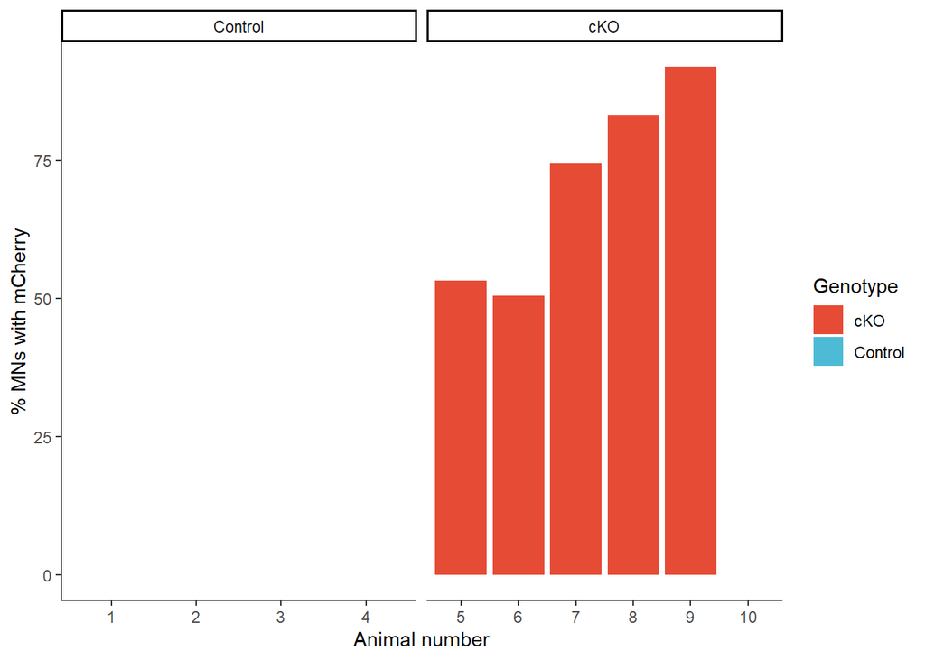

```r
quants[is.na(quants)] <- 0

quants_a241 <- quants


ggplot(quants, aes(x = factor(label), y = 100*frac_vacht_with_mcherry,
                   fill = genotype)) +
  geom_bar(stat="identity") +
  facet_wrap(~factor(genotype, levels = c("Control", "cKO")),
                     scale = "free_x") +
  ylab("% MNs with mCherry") +
  theme_classic() +
  ggsci::scale_fill_npg() +
  xlab("Animal number") +
  ggeasy::easy_add_legend_title("Genotype")
```

```r
ggsave("markdown_images/AAV/pc_mCherry_MNs.pdf", height = 4.5, width = 8, units="cm")

# ggplot(quants, aes(x = factor(label), y = 100*frac_vacht_with_TDP,
#                    fill = genotype)) +
#   geom_bar(stat="identity") +
#   facet_wrap(~factor(genotype, levels = c("Control", "cKO")),
#                      scale = "free_x") +
#   ylab("% MNs with TDP-43") +
#   theme_classic() +
#   ggsci::scale_fill_npg() +
#   xlab("Animal number") +
#   ggeasy::easy_add_legend_title("Genotype")
```

And now the same for the positive control vector

```r
quants <- read_csv(paste0(data_dir, "AAV/A245_quantifications3.csv")) %>%
    filter(!is.na(triple)) %>%
    mutate(mcherry = vacht_and_mcherry) %>%
  mutate(vacht = as.numeric(vacht)) %>%
  # Compute some useful values
  mutate(n_mcherry_no_vacht = mcherry - vacht_and_mcherry,
         n_vacht_no_tdp = vacht - tdp_and_vacht) %>%

  group_by(Aminal_ID) %>%
  # Compute summaries per animal
  mutate(total_n_mcherry = sum(mcherry),
         total_n_vacht_and_mcherry = sum(vacht_and_mcherry),
         total_n_vacht = sum(vacht),
         total_n_vacht_and_tdp = sum(tdp_and_vacht),
         total_n_mcherry_no_vacht = sum(n_mcherry_no_vacht),
         total_n_vacht_no_tdp = sum(n_vacht_no_tdp),
         total_n_triple = sum(triple),
         total_n_tdp = sum(vacht - n_vacht_no_tdp)) %>%

  select(Aminal_ID, contains("total")) %>%
  distinct() %>%

  # Answer question 1:
  mutate(frac_vacht_with_TDP = total_n_vacht_and_tdp/total_n_vacht) %>%

  # Answer question 2:
  mutate(frac_vacht_with_mcherry = total_n_vacht_and_mcherry/total_n_vacht) %>%

  # Answer question 4:
  mutate(n_vacht_mcherry_and_tdp = total_n_triple,
         n_vacht_mcherry_no_tdp = total_n_vacht_and_mcherry - total_n_triple,
         n_vacht_tdp_no_mcherry = total_n_vacht_and_tdp - total_n_triple) %>%
  mutate(n_vacht_no_mcherry_no_tdp = total_n_vacht - n_vacht_mcherry_and_tdp - n_vacht_mcherry_no_tdp - n_vacht_tdp_no_mcherry) %>%

  mutate(genotype = "Control") %>%
  ungroup() %>%
  arrange(desc(genotype)) %>%
  mutate(label = 1:n())
```

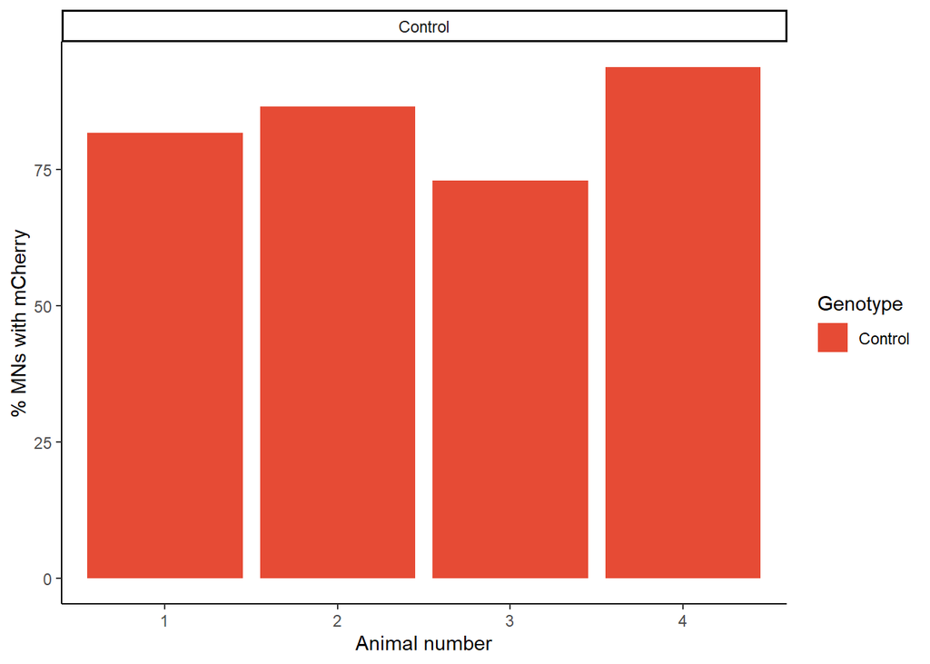

```r
quants_a245 <- quants


ggplot(quants, aes(x = factor(label), y = 100*frac_vacht_with_mcherry,
                   fill = genotype)) +
  geom_bar(stat="identity") +
  facet_wrap(~factor(genotype, levels = c("Control", "cKO")),
                     scale = "free_x") +
  ylab("% MNs with mCherry") +
  theme_classic() +
  ggsci::scale_fill_npg() +
  xlab("Animal number") +
  ggeasy::easy_add_legend_title("Genotype")
```

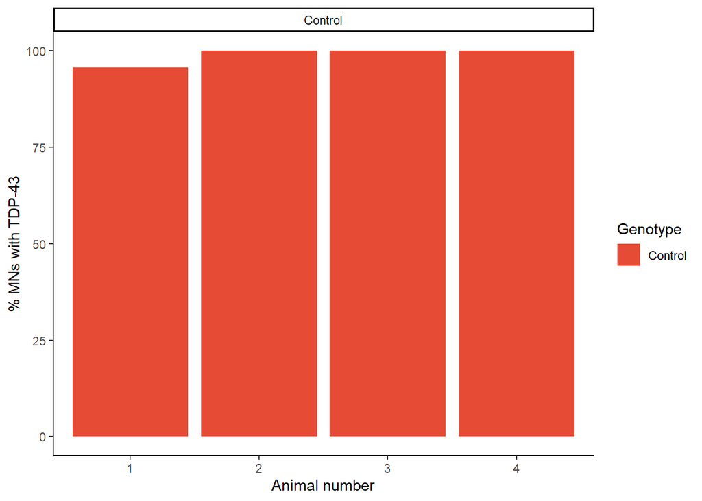

```r
#ggsave("markdown_images/AAV/pc_mCherry_MNs.pdf", height = 4.5, width = 8, units="cm")

ggplot(quants, aes(x = factor(label), y = 100*frac_vacht_with_TDP,
                   fill = genotype)) +
  geom_bar(stat="identity") +
  facet_wrap(~factor(genotype, levels = c("Control", "cKO")),
                     scale = "free_x") +
  ylab("% MNs with TDP-43") +
  theme_classic() +
  ggsci::scale_fill_npg() +
  xlab("Animal number") +
  ggeasy::easy_add_legend_title("Genotype")
```

Now let’s combine the quantifications for all three vectors

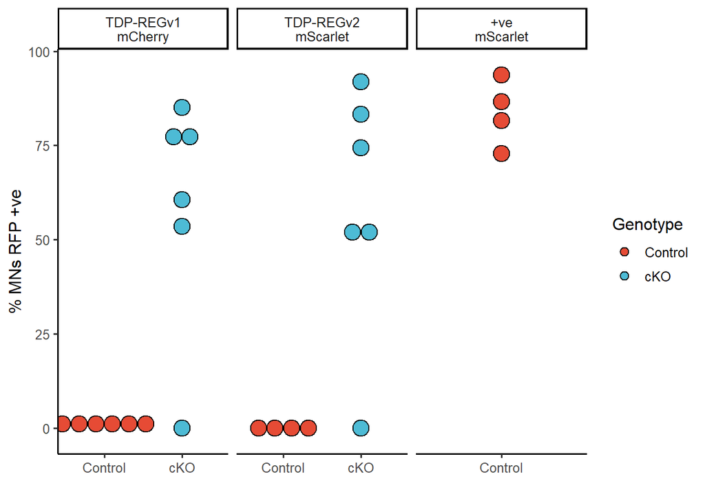

```r
combined_quants <- bind_rows(quants_a244 %>% mutate(vector = "TDP-REGv1\nmCherry"),
                             quants_a241 %>% mutate(vector = "TDP-REGv2\nmScarlet")) %>%
  bind_rows(quants_a245 %>% mutate(vector = "+ve\nmScarlet")) %>%
  mutate(vector = factor(vector, levels = c("TDP-REGv1\nmCherry", "TDP-REGv2\nmScarlet", "+ve\nmScarlet"))) %>%
  mutate(genotype = factor(genotype, levels = c("Control", "cKO")))

ggplot(combined_quants, aes(x = genotype, y = 100*frac_vacht_with_mcherry,
                            fill = genotype)) +
  geom_dotplot(binaxis = "y", stackdir = "center", binwidth = 4, dotsize = 1.1) +
  facet_wrap(~vector, scales = "free_x") +
  ylab("% MNs RFP +ve") +
  ggpubr::theme_classic2() +
  xlab("") +
  ggeasy::easy_add_legend_title("Genotype") +
  ggsci::scale_fill_npg()
```

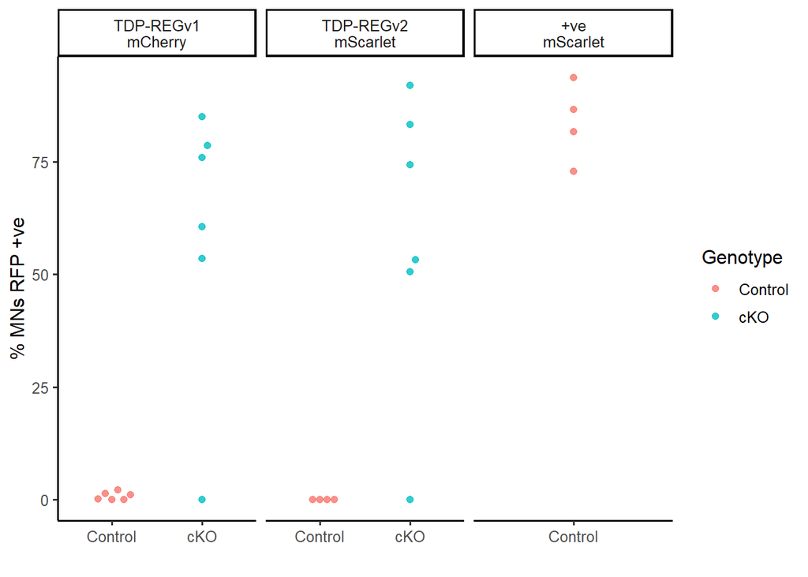

```r
ggplot(combined_quants, aes(x = genotype, y = 100*frac_vacht_with_mcherry,
                            colour = genotype)) +

  #geom_quasirandom(varwidth = TRUE) +
  geom_beeswarm(cex = 4, method = "compactswarm", size = 1.8, alpha = 0.8) +
  facet_wrap(~vector, scales = "free_x") +
  ylab("% MNs RFP +ve") +
  ggpubr::theme_classic2() +
  xlab("") +
  ggeasy::easy_add_legend_title("Genotype") +
  ggsci::scale_fill_npg()
```

```r
ggsave("markdown_images/AAV/pc_TDP43_MNs_combined_quants_incl_a245.pdf", height = 5.5, width = 12, units="cm")


# ggplot(combined_quants, aes(x = genotype, y = 100*frac_vacht_with_TDP,
#                             fill = genotype)) +
#   geom_dotplot(binaxis = "y", stackdir = "center") +
#   facet_wrap(~factor(genotype, levels = c("Control", "cKO")),
#                      scale = "free_x") +
#   ylab("% MNs with TDP-43") +
#   theme_classic() +
#   ggsci::scale_fill_npg() +
#   xlab("Animal number") +
#   ggeasy::easy_add_legend_title("Genotype") +
#   facet_wrap(~vector)
```

# Incucyte with 12QN TDP-43

We transfected various mScarlet reporters into HEK293T cells with either SNAP-12QN-TDP-43 or just a plain Halo tag not attached to anything. We added a little bit of mGreenLantern plasmid to all of them too, just to check that the transfection worked. Note that the first two rows went a little bit wrong during transfection - volume was lost, so the last couple didn’t work.

Also, it seems like the Design 1 AARS1-mCherry transfection failed. The plasmid had been stored at 4 degrees (instead of frozen) for an extended period so I assume this is why. I saw similar problems in another transfection.

We’ll ignore this row.

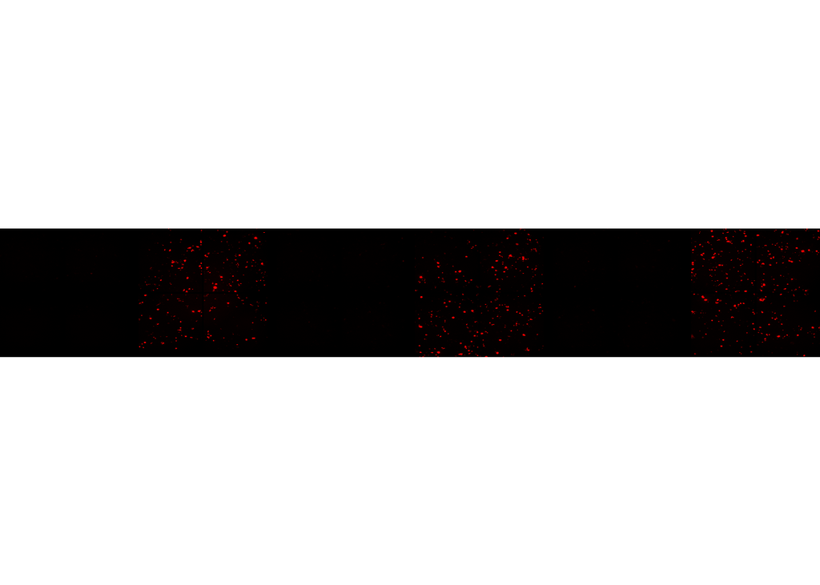

```r
generate_full_image <- function(combined_positions, all_images, n_rows,
                                n_columns=6, dim_image=200, spacing_images=5,
                                spacing_wells=30, background_quantile=0.97){

  # This function makes a plot from incucyte data.
  # You need to supply a "combined_positions" dataframe that has values for
  # plate, well and Order

  # Currently it only works when you have four images per well (stupidly named "replicates")

  height <- n_rows*(2*dim_image + spacing_images) + (n_rows-1)*spacing_wells + 1
  width <- n_columns*(2*dim_image + spacing_images) + (n_columns-1)*spacing_wells + 1

  full_image <- matrix(nrow = height, ncol = width, 0)

  background <- 10000000 # set arbitrarily large initial value

  for(image in all_images){
    filename <- word(image, sep="/", start=-1, end = -1)
    plate <- paste(ifelse(str_detect(image, "control plate"), 2, 1))

    well = word(filename, sep="_", start=2, end=2)
    plate_column = as.numeric(str_sub(well, 2, 3))

    image_column = ifelse(plate_column %% 6 == 0, 6, plate_column %% 6)
    image_row = unique(combined_positions$Order[which(combined_positions$well == well &
                                                        combined_positions$Plate == plate)])

    if(is.na(image_row)){
      next
    }

    if("replicate" %in% colnames(combined_positions)){
      replicate <- combined_positions$replicate[which(combined_positions$filename == filename)]
    } else {
      replicate = as.numeric(word(filename, sep="_", start=3, end=3))
    }

    image_matrix <- readImage(image)
    smaller <- as.array(EBImage::resize(image_matrix, w=dim_image, h=dim_image))

    well_top_left_x = (image_column - 1)*(2*dim_image + spacing_images + spacing_wells) + 1

    image_top_left_x = well_top_left_x + ifelse(replicate %in% c(2,4), dim_image + spacing_images, 0)

    well_top_left_y = (image_row - 1)*(2*dim_image + spacing_images + spacing_wells) + 1

    image_top_left_y = well_top_left_y + ifelse(replicate %in% c(3,4), dim_image + spacing_images, 0)

    full_image[image_top_left_y:(image_top_left_y+dim_image-1),
               image_top_left_x:(image_top_left_x + dim_image-1)] <- smaller

    this_background <- quantile(smaller, 0.05)

    if(this_background < background){
      background <- this_background
    }
  }

  full_image2 <- full_image - background
  img_invert <- Image(1 - t(full_image2/quantile(full_image2, background_quantile)))

  return(img_invert)
}

red_12qn <- Sys.glob(paste0(data_dir, "12qn from incucyte/red/*"))

just_a11 = red_12qn[which(str_detect(red_12qn, "VID411_D"))]


positions <- data.frame(filename = word(red_12qn, -1, sep="/")) %>%
  mutate(well = word(filename, 2, sep="_"),
         replicate = as.numeric(word(filename, 3, sep="_"))) %>%
  mutate(row = str_sub(well, 1, 1),
         column = as.numeric(str_sub(well, 2, 2))) %>%
  left_join(data.frame(row = c("A", "B", 'C', 'D', 'E', 'F', 'G', 'H'),
                       Order = c(1, 2, 3, 4, 5, 6, 7, 8))) %>%
  mutate(plate_column = column) %>%
  mutate(Plate = 1) %>%
  filter(row == "D") %>%
  mutate(Order =1) %>%
  mutate(replicate = case_when(replicate == 2 ~ 3,
                               replicate == 3 ~ 2,
                               T ~ replicate))
im <- generate_full_image(positions, just_a11, n_rows = 1, background_quantile = 0.995)

green_12qn <- Sys.glob(paste0(data_dir, "12qn from incucyte/green/*"))

just_a11_green = green_12qn[which(str_detect(red_12qn, "VID411_D"))]

positions_green <- data.frame(filename = word(green_12qn, -1, sep="/")) %>%
  mutate(well = word(filename, 2, sep="_"),
         replicate = as.numeric(word(filename, 3, sep="_"))) %>%
  mutate(row = str_sub(well, 1, 1),
         column = as.numeric(str_sub(well, 2, 2))) %>%
  left_join(data.frame(row = c("A", "B", 'C', 'D', 'E', 'F', 'G', 'H'),
                       Order = c(1, 2, 3, 4, 5, 6, 7, 8))) %>%
  mutate(plate_column = column) %>%
  mutate(Plate = 1) %>%
  filter(row == "D") %>%
  mutate(Order =1) %>%
  mutate(replicate = case_when(replicate == 2 ~ 3,
                               replicate == 3 ~ 2,
                               T ~ replicate))
im_green <- generate_full_image(positions_green, just_a11_green, n_rows = 1, background_quantile = 0.97)

rgb_red <- rgbImage(red = (1-im), green = NULL, blue = NULL)
display(rgb_red)
```

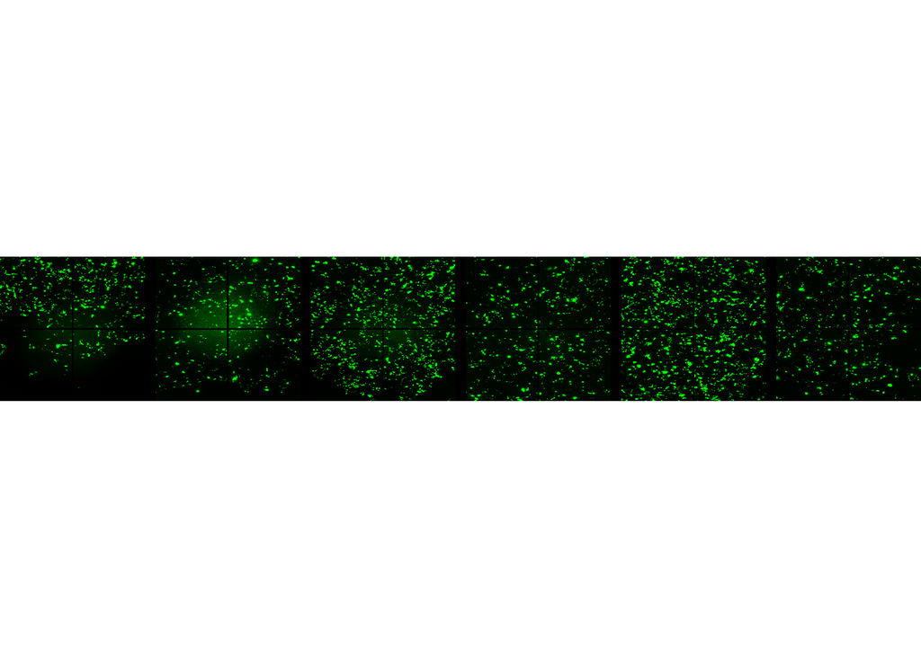

```r
writeImage(rgb_red, "markdown_images/12QN incucyte/red_a11.png", quality=99)

rgb_green <- rgbImage(red = NULL, green = 1-im_green, blue = NULL)
display(rgb_green)
```

```r
writeImage(rgb_green, "markdown_images/12QN incucyte/green_a11.png", quality=99)
```

# Prime editing

## Calculate the % editing

```r
all_files <- Sys.glob(paste0(data_dir, "Prime editing/pileup 8th nov 22/*.csv.gz"))

all_files <- all_files[!str_detect(all_files, "no_match")]

for(file in all_files){
  print(file)
  code = word(file, -1, -1, sep="/")

  this_df <- read_csv(file) %>%
    mutate(filename = code)

  if(file == all_files[1] && nrow(this_df) > 0){
    all_df <- this_df
  } else {
    if(nrow(this_df) > 0){
      all_df <- bind_rows(all_df, this_df)
    }
  }
}
```

[output not shown]

[output not shown]

[output not shown]

[output not shown]

[output not shown]

[output not shown]

[output not shown]

[output not shown]

[output not shown]

[output not shown]

[output not shown]

[output not shown]

[output not shown]

[output not shown]

[output not shown]

[output not shown]

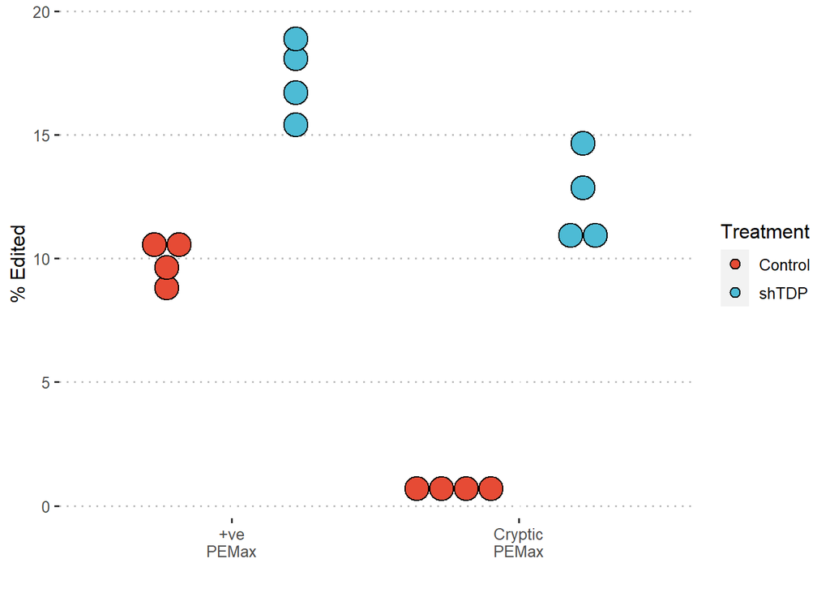

```r
just_unc <- all_df %>%
  filter(reference_name == 0) %>%
  arrange(filename, position) %>%
  group_by(filename, position, insertion_number) %>%
  mutate(n_this_pos = sum(n)) %>%
  mutate(frac_this_pos = n/n_this_pos) %>%
  ungroup() %>%
  mutate(f_bc = as.numeric(word(filename, 5, 5, sep="_")),
         r_bc = as.numeric(word(filename, 9, 9, sep="_|\\."))) %>%
  mutate(treatment = ifelse(f_bc == 11, "Control", "shTDP"),
         Plasmid = ifelse(r_bc <= 4, "12C", "PEMax"))

peg10_561 <- just_unc %>%
  filter(position == 561) %>%
  filter(position == 561 & nt %in% c("G", "C")) %>%
  filter(insertion_number == 0) %>%
  ungroup() %>%
  group_by(filename) %>%
  mutate(frac_c = ifelse(sum(as.numeric(nt == "C")) == 0, 0, max(ifelse(nt == "C", frac_this_pos, -1)))) %>%
  mutate(new_name = ifelse(Plasmid == "PEMax", "Constitutive", "Cryptic"))

peg10_561_summary2 <- peg10_561 %>%
  ungroup() %>%
  dplyr::select(Plasmid, treatment, frac_c) %>%
  ungroup() %>%
  group_by(Plasmid, treatment) %>%
  mutate(mean_p = 100*mean(frac_c),
         sd_p = 100*sd(frac_c)) %>%
  unique() %>%
  mutate(new_name = ifelse(Plasmid == "PEMax", "+ve\nPEMax", "Cryptic\nPEMax"))

ggplot(peg10_561_summary2, aes(x = new_name, y = 100*frac_c, fill = treatment)) +
  geom_dotplot(binaxis = "y", position = "dodge",dotsize = 2, binwidth = 0.5, stackdir = "center") +
  ggpubr::theme_pubclean() +
  ggeasy::easy_add_legend_title("Treatment") +
  ylab("% Edited") +
  #geom_errorbar(position="dodge", aes(ymin = mean_p-sd_p, ymax = mean_p+sd_p)) +
  #ggtitle("Editing of UNC13A cryptic\ndonor splice site") +
  xlab("") +
  ggsci::scale_color_npg() +
  ggsci::scale_fill_npg() +
  ggeasy::easy_move_legend("right")
```

```r
ggsave("markdown_images/PE/dotplot_nanopore_summary.pdf", height = 6.5, width = 8, units = "cm")
```

# TDP-43 Raver

## Analyse Qiaxcel of 2FL mutant

These datasets are from a capillary electrophoresis machine (“QIAxcel”)

The below R scripts use the raw data from this machine to produce the desired plots

```r
raw_filename <- paste0(data_dir, "Raver/2FL qiaxcel/design2tdptests_20221015_061200_Rw.csv")

df <- read_tsv(raw_filename) %>%
  pivot_longer(cols = contains("RFU")) %>%
  mutate(sample = as.numeric(str_sub(name,6, 7)))  %>%
  select(Time, Row, sample, value) %>%
  mutate(plasmid = case_when(
    Row == "A" & sample <= 6 ~ "mScarlet (-ve control)",
    Row == "B" & sample <= 6 ~ "Plasmid B02",
    Row == "C" & sample <= 6 ~ "Plasmid B03",
    Row == "D" & sample <= 6 ~ "Plasmid B04",
    Row == "E" & sample <= 6 ~ "Plasmid B05",
    Row == "F" & sample <= 6 ~ "Plasmid B06",
    Row == "A" & sample > 6 ~ "Plasmid B09",
    Row == "B" & sample > 6 ~ "Plasmid B10",
    Row == "C" & sample > 6 ~ "Plasmid B11",
    Row == "D" & sample > 6 ~ "Plasmid B07",
    Row == "E" & sample > 6 ~ "Plasmid B08",
    Row == "F" & sample < 11 ~ "Plasmid B11 -RT",
    Row == "F" & sample == 11 ~ "Water input",
    Row == "F" & sample == 12 ~ "+ve control")) %>%
  mutate(actual_sample_no = ifelse(sample %% 6 == 0, 6, sample %% 6)) %>%
  group_by(plasmid, actual_sample_no) %>%
  mutate(norm_value = value/max(value)) %>%
  arrange(Time) %>%
  mutate(rollmean = zoo::rollmean(norm_value, k=10, na.pad=T)) %>%
  mutate(rollmean2 = ifelse(is.na(rollmean), 0, rollmean)) %>%
  # Define some backgrounds
  mutate(is_above_background = case_when(plasmid =="Plasmid B02" ~ rollmean2 > quantile(norm_value, 0.98, na.rm=T),
                                         plasmid =="mScarlet (-ve control)" ~ rollmean2 > quantile(norm_value, 0.98, na.rm=T),
                                         plasmid =="Plasmid B07" & actual_sample_no==5 ~ rollmean2 > quantile(norm_value, 0.98, na.rm=T),
                                         plasmid =="Water input" & actual_sample_no==5 ~ rollmean2 > quantile(norm_value, 0.98, na.rm=T),
                                         T ~ rollmean2 > quantile(norm_value, 0.95, na.rm=T))) %>%
  mutate(lower_marker = min(ifelse(is_above_background, Time, 1000000000)),
         upper_marker = max(ifelse(is_above_background, Time, -100000))) %>%
  mutate(normalised_time = round((Time-lower_marker)/(upper_marker-lower_marker),3)) %>%
  filter(normalised_time > 0 & normalised_time < 1) %>%
  #filter(!(plasmid == "Plasmid B10" & actual_sample_no == 6)) %>%
  mutate(treatment = ifelse(actual_sample_no %% 2 == 0, "shTDP", "NT"))
```

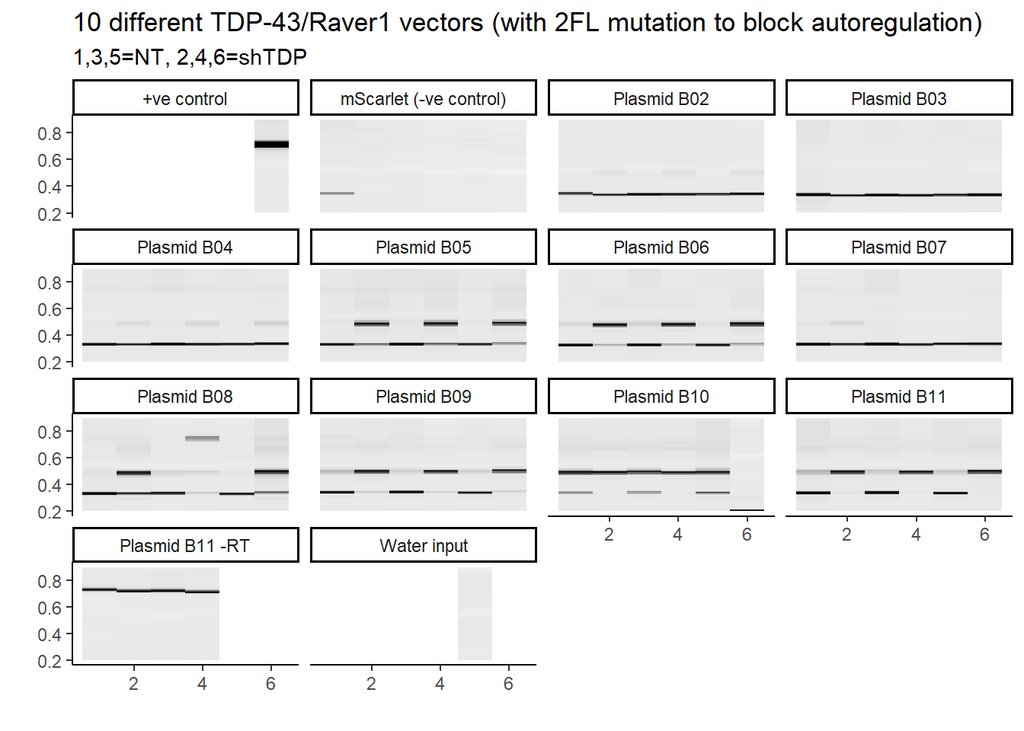

```r
# First, let's plot these all

ggplot(df,
       aes(x=actual_sample_no, y=normalised_time, fill=norm_value)) +
  geom_tile() +
  scale_fill_gradient(low="white", high="black") +
  theme_classic() +
  facet_wrap(~factor(plasmid)) +
  ggtitle("10 different TDP-43/Raver1 vectors (with 2FL mutation to block autoregulation)",
          "1,3,5=NT, 2,4,6=shTDP") +
  ylab("") +
  xlab("") +
  ggeasy::easy_remove_legend() +
  ylim(0.2,0.9)
```

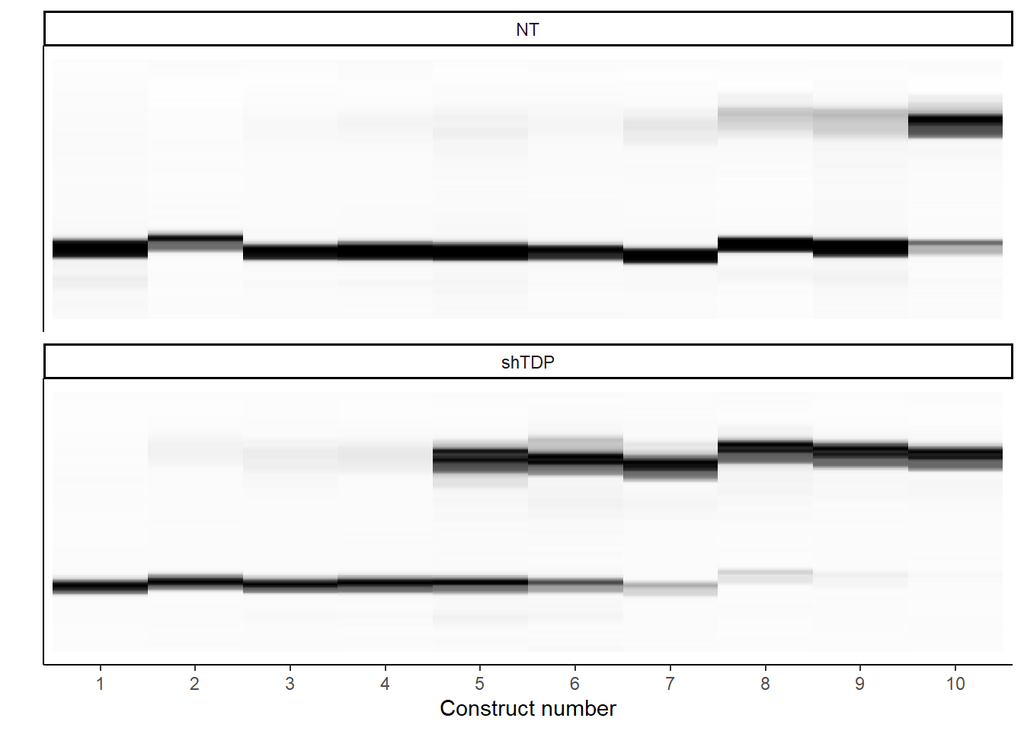

```r
# Now, let's plot the 2FL gradient to make it pretty

ordered_names <- data.frame(plasmid = c("Plasmid B03", "Plasmid B02",
                                        "Plasmid B04", "Plasmid B07",
                                        "Plasmid B08", "Plasmid B05",
                                        "Plasmid B06", "Plasmid B09",
                                        "Plasmid B11", "Plasmid B10"),
                            construct_number = factor(1:10))

df2 <- df %>%
  inner_join(ordered_names)
ggplot(df2 %>% filter(actual_sample_no <= 2),
       aes(x=construct_number, y=normalised_time, fill=norm_value)) +
  geom_tile() +
  scale_fill_gradient(low="white", high="black") +
  theme_classic() +
  facet_wrap(~treatment, ncol = 1) +
  ylab("") +
  xlab("Construct number") +
  ggeasy::easy_remove_legend() +
  ylim(0.25,0.57) +
  theme(axis.text.y=element_blank(),
        axis.ticks.y=element_blank())
```

```r
ggsave("markdown_images/Raver/2FL_gradient.pdf", height = 6, width = 6, units="cm")
```

## Analyse RT-PCRs of UNC13A, STMN2 and AARS1

To determine whether these constructs resist cryptic splicing, we performed RT-PCRs against UNC13A, STMN2 and AARS1. We ran these on a QIAxcel.

To analyse the QIAxcel data, I wrote a small R package, QIAxcelR.

The samples are loaded in a slightly funky order. The positions are in the “QIAxcel positions.csv” file. Row A refers to the first row of each pair, and Row D refers to the second row of each pair. Column positions and first versus second row is consistent for all pairs.

Annoyingly I lost one replicate of mScarlet untreated. However, this is not a particularly important sample because all of the untreated samples tend to be very similar (mScarlet dox/shTDP is much more important, for example)

First, let’s analyse unc13a in isolation

```r
py <- import("pybaselines")
scipy <- import("scipy")

unc_csv <- paste0(data_dir, "Raver/qiaxcel of unc13a stmn2 aars1/Unc13a 21st June/C220830A16_2023-06-22_2125_20230622_075330_Rw.csv")

positions <- read_csv(paste0(data_dir, "Raver/qiaxcel of unc13a stmn2 aars1/Unc13a 21st June/QIAxcel positions.csv")) %>%
  pivot_longer(cols = !contains("Row")) %>%
  dplyr::rename(row = `Row/col`, column = name, sample_name = value) %>%
  mutate(replicate = as.numeric(word(sample_name, -1)),
         plasmid = factor(word(sample_name, 1), levels = c("RV", "B5", "B11", "mScar", "-ve")),
         treatment = ifelse(str_detect(sample_name, "NT"), "NT", "shTDP")) %>%
  mutate(column = as.numeric(column))
df <- parse_qiaxcel_output(unc_csv)
```

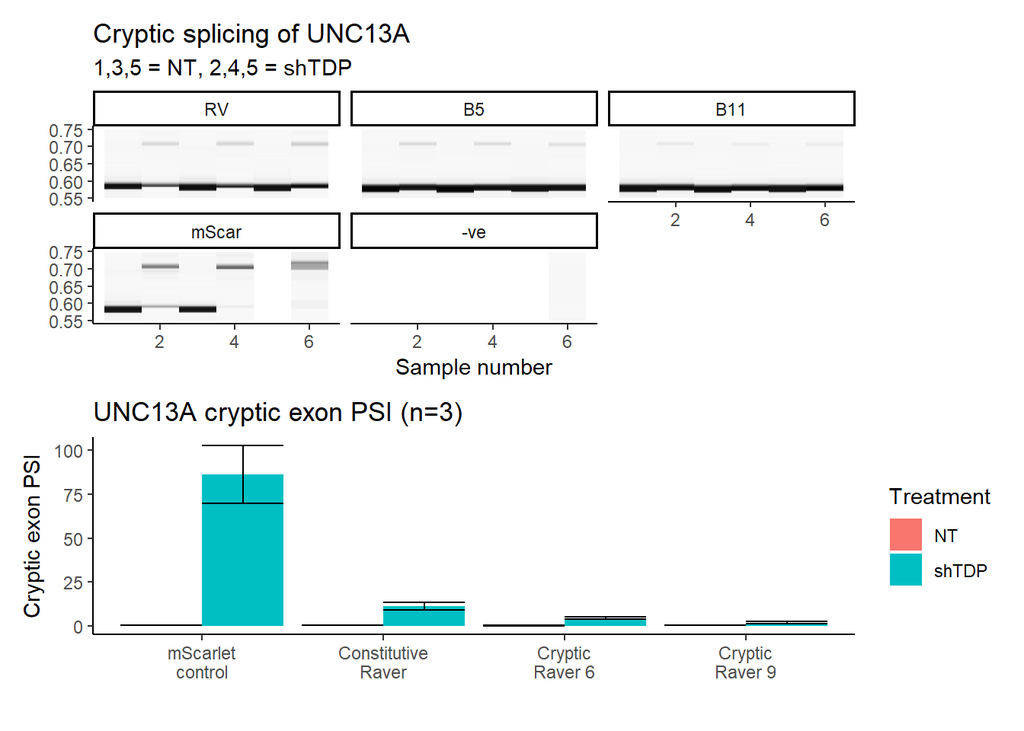

```r
df2 <- preprocess_dataframe(df)

tweak_df <- data.frame(unique_id = "D12", shift = 0, multiply = 0.97)

df3 <- tweak_positions(df2, tweak_df)

df4 <- df3 %>%
  mutate(column = as.numeric(column)) %>%
  left_join(positions, by = c("row","column")) %>%
  mutate(actual_sample_no = ifelse(plasmid == "-ve", 6, 2*replicate - 1 + as.numeric(treatment == "shTDP")))

unc_final_data <- df4

p1 <- ggplot(df4,
       aes(y = index_for_plotting, fill = corrected_value, x = actual_sample_no)) +
  geom_tile() +
  theme_classic() +
  scale_fill_gradient(low = "white", high = "black") +
  ylim(0.55,0.75) +
  facet_wrap(~plasmid) +
  ggtitle("Cryptic splicing of UNC13A", "1,3,5 = NT, 2,4,5 = shTDP") +
  xlab("Sample number") +
  ylab("") +
  ggeasy::easy_remove_legend()


yo <- find_molar_ratios(df3, lower_band_pos = 0.58, lower_band_width = 0.02, lower_band_nts = 405,
                        upper_band_pos= 0.715, upper_band_width = 0.03, upper_band_nts = 405+128) %>%
  left_join(positions %>% mutate(unique_id = paste0(row, column))) %>%
  filter(!is.na(replicate)) %>%
  ungroup() %>%
  group_by(plasmid, treatment) %>%
  mutate(psi = 100*(1-molar_fraction_lower_band)) %>%
  mutate(average_psi = mean(psi)) %>%
  mutate(sd_psi = sd(psi)) %>%
  mutate(good_names = factor(case_when(plasmid == "RV" ~ "Constitutive\nRaver",
                                plasmid == "B5" ~ "Cryptic\nRaver 6",
                                plasmid == "B11" ~ "Cryptic\nRaver 9",
                                plasmid == "mScar" ~ "mScarlet\ncontrol"),
         levels = c("mScarlet\ncontrol","Constitutive\nRaver","Cryptic\nRaver 6","Cryptic\nRaver 9")))
unc_ratios <- yo

p2 <- ggplot(yo %>% distinct(average_psi, .keep_all=T), aes(x = good_names, y = average_psi, fill = treatment)) +
  geom_bar(stat="identity", position= "dodge", alpha = 1) +
  ylab("Cryptic exon PSI") +
  geom_errorbar(aes(ymin = average_psi-sd_psi,
                            ymax = average_psi+sd_psi),
             position = position_dodge(width = 0.9)) +
  theme_classic() +
  ggtitle("UNC13A cryptic exon PSI (n=3)") +
  ggeasy::easy_add_legend_title("Treatment") +
  xlab("")

p1 / p2
```

Let’s also make a quick plot of representative examples

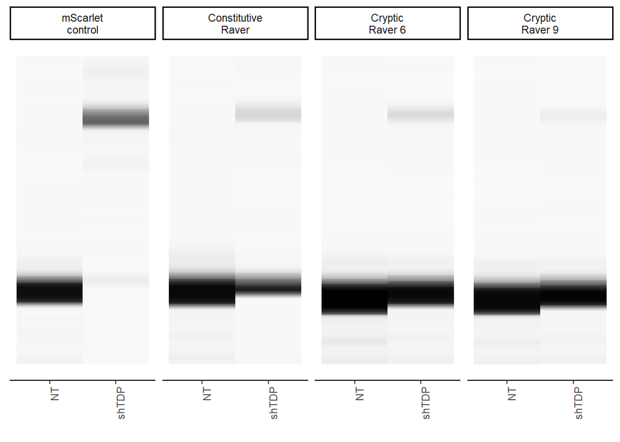

```r
ggplot(unc_final_data %>% filter(actual_sample_no %in% c(3, 4)) %>%
           mutate(good_names = factor(case_when(plasmid == "RV" ~ "Constitutive\nRaver",
                                plasmid == "B5" ~ "Cryptic\nRaver 6",
                                plasmid == "B11" ~ "Cryptic\nRaver 9",
                                plasmid == "mScar" ~ "mScarlet\ncontrol"),
         levels = c("mScarlet\ncontrol","Constitutive\nRaver","Cryptic\nRaver 6","Cryptic\nRaver 9"))) %>%
         mutate(sample_label = ifelse(actual_sample_no == 3, "NT", "shTDP")),
       aes(y = index_for_plotting, fill = corrected_value, x = sample_label)) +
  geom_tile() +
  theme_classic() +
  scale_fill_gradient(low = "white", high = "black") +
  ylim(0.53,0.75) +
  facet_wrap(~good_names, ncol = 4) +
  xlab("Sample number") +
  ylab("") +
  ggeasy::easy_remove_legend() +
  ggeasy::easy_rotate_x_labels(side = "right") +
  theme(axis.title.y=element_blank(),
        axis.text.y=element_blank(),
        axis.ticks.y=element_blank()) +
  xlab("") +
  ggeasy::easy_remove_y_axis()
```